# Lettuce Demand Forecasting in Berkeley, CA and New York, NY

### STL Decomposition and Visualisation

The bar on the seasonal pattern is larger than the grey bar on the data panel. This indicates that the seasonal signal is large relative to the variation in the data. The trend panel is the largest box compared to the data and seasonal boxes, this indicates that the variation attributed to the trend is much smaller than the seasonal components and is consequently only a small part of the variation in the data series. The variation attributed to the trend is considerably smaller than the stochastic component (the remainders). As such, we can deduce that these data do not exhibit a trend.

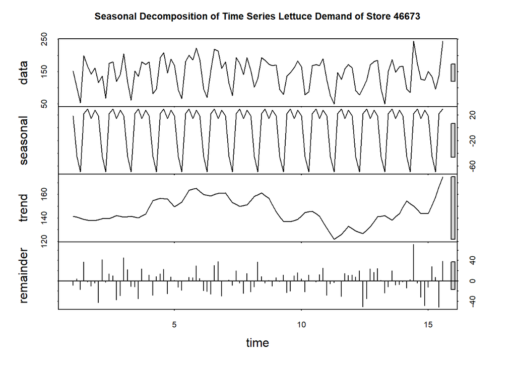

```r
##  Viusalising the data, with its seasonal, trend and remainder component.
plot(stl(ts_store_46673, s.window = "period"), main="Seasonal Decomposition of Time Series Lettuce Demand of Store 46673", xaxt = 'n')
```

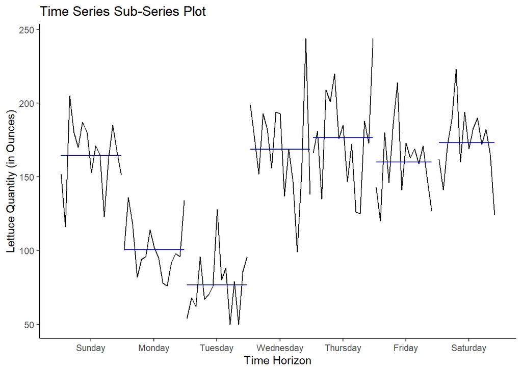

```r
## Various other ggplot2 package plots are used to gain understanding of the data
ggsubseriesplot(ts_store_46673, main = 'Time Series Sub-Series Plot', ylab = 'Lettuce Quantity (in Ounces)', xlab = 'Time Horizon') +
  theme(panel.grid.major = element_blank(), panel.grid.minor = element_blank(), panel.background = element_blank(), axis.line = element_line(colour = "black"))
```

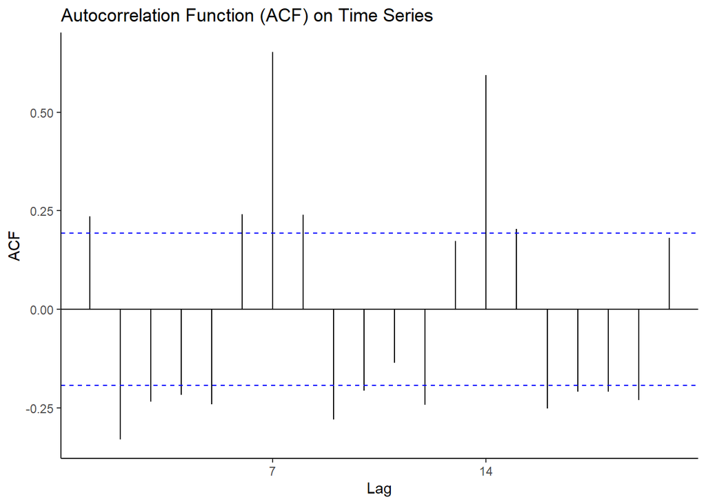

```r
ggAcf(ts_store_46673, main = 'Autocorrelation Function (ACF) on Time Series') +
  theme(panel.grid.major = element_blank(), panel.grid.minor = element_blank(), panel.background = element_blank(), axis.line = element_line(colour = "black"))
```

### Initial Holt-Winters and ETS Functions

Initially, a “ZZZ” model is created in order to have R automatically fit the Error, Trend and Seasonality values of the time series. This initial model will return letters which will be used throughout the remaineder of the store number 46673 forecast process.

The Holt-Winters model, the fitted ETS model and the actual time series are plotted for visual interpretability.

```r
## Initial Holt-Winters with exponential smoothing
HW_store_46673 <- HoltWinters(ts_store_46673, beta = FALSE)

## Initial ETS model with automatic fitting for the E, T, S
ets_store_46673 <- ets(ts_store_46673, model = 'ZZZ')
ets_store_46673 ## Automatic model concludes a M,N,A model is best for this data
```

```
## ETS(M,N,A)
##
## Call:
##  ets(y = ts_store_46673, model = "ZZZ")
##
##   Smoothing parameters:
##     alpha = 1e-04
##     gamma = 1e-04
##
##   Initial states:
##     l = 145.6322
##     s = 26.823 13.9141 30.6986 24.3151 -66.7508 -45.1285
##            16.1285
##
##   sigma:  0.1898
##
##      AIC     AICc      BIC
## 1163.044 1165.435 1189.391
```

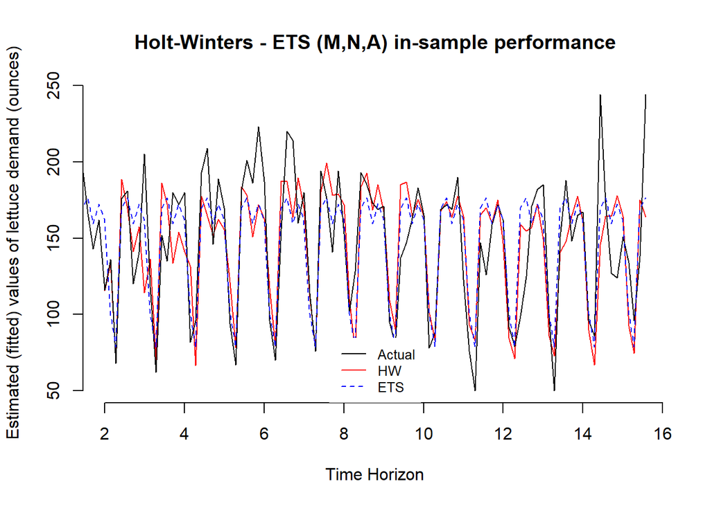

```r
plot(HW_store_46673, main="Holt-Winters - ETS (M,N,A) in-sample performance", xlab="Time Horizon",
     ylab="Estimated (fitted) values of lettuce demand (ounces)", lty = 1, col = "black", frame.plot = FALSE)
lines(fitted(ets_store_46673), col = "blue", lty = 2)
legend("bottom", legend=c("Actual","HW", "ETS"), col=c("black", "red", "blue"), box.lty=0, lty=c(1,1,2), cex=0.8)
```

### Training and Test Set

The test set needs to be the most recent part of the data as the idea is to simulate a production environment, where after the model is trained it would be evaluated on data it had not seen. Throughout this forecasting project an 80:20 split is used. That is, 80% of the time series data will be attributed to the training set and the most recent 20% will be used for the test set.

```r
## Training and Test sets (83 days, 80%)
training_ts_store_46673 <- ts(store_46673[1:83,2], frequency = 7)
length(training_ts_store_46673)
```

```
## [1] 83
```

```r
## Test set (20 days, 20%)
test_ts_store_46673 <- store_46673[84:nrow(store_46673),2]
length(test_ts_store_46673)
```

```
## [1] 20
```

```r
length(test_ts_store_46673) + length(training_ts_store_46673) ## Length of training set and test set combined
```

```
## [1] 103
```

```r
length(ts_store_46673) ## Length of time series
```

```
## [1] 103
```

### Creating, Forecasting and Visualizing Holt-Winters on Training Set

The initial Holt-Winters model will now be trained on in-sample data and it will forecast 20 days past the last day of the training data. This is done using the forecast()function which takes the model and a argument, h, the number of periods it should forecast.

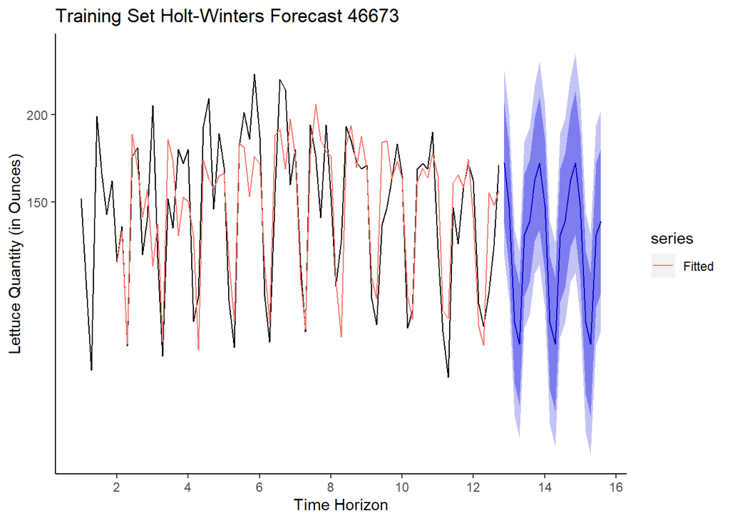

```r
## Creating Holt-Winters filtering of the training time series for store 46673. Beta is set to false to force exponential smoothing
training_HW_store_46673 <- HoltWinters(training_ts_store_46673, beta = FALSE)
forecast_HW1_store_46673 <- forecast(training_HW_store_46673, h = 20)

autoplot(forecast_HW1_store_46673, main = 'Training Set Holt-Winters Forecast 46673', ylab = 'Lettuce Quantity (in Ounces)',
         xlab = 'Time Horizon', xlab = 'Time Horizon') +
  autolayer(fitted(forecast_HW1_store_46673), series = 'Fitted', na.rm=TRUE) +
  scale_x_continuous(breaks = seq(0, 16, by = 2)) +
  scale_y_continuous(breaks = c(150, 200, 250, 300, 350, 400, 450))  +
  theme(panel.grid.major = element_blank(), panel.grid.minor = element_blank(), panel.background = element_blank(),
        axis.line = element_line(colour = "black"))
```

The initial ETS model with a model paramet = ‘MNA’, a model with an additive level and seasonal component, will now be trained on in-sample data and it will forecast 20 days past the last day of the training data. This is done using the forecast()function which takes the model and a argument, h, the number of periods it should forecast.

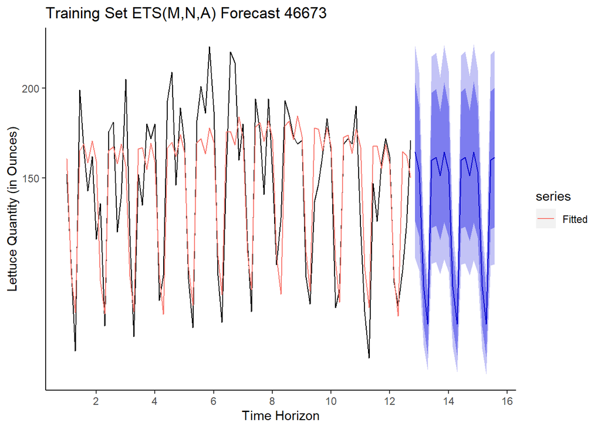

```r
## ## ETS models use maximum likelihood, the probability of the data arising from the specified model. ETS automatically chooses the best type of model. Convenient for forecasting timeseries that have trends or seasonality. Lets explore...
training_ets_store_46673 <- ets(training_ts_store_46673, model = 'MNA')
forecast_ets_store_46673 <- forecast(training_ets_store_46673, h = 20)

autoplot(forecast_ets_store_46673, main = 'Training Set ETS(M,N,A) Forecast 46673', ylab = 'Lettuce Quantity (in Ounces)',
         xlab = 'Time Horizon', xlab = 'Time Horizon') +
  autolayer(fitted(forecast_ets_store_46673), series = 'Fitted', na.rm=TRUE) +
  scale_x_continuous(breaks = seq(0, 16, by = 2)) +
  scale_y_continuous(breaks = c(150, 200, 250, 300, 350, 400, 450)) +
  theme(panel.grid.major = element_blank(), panel.grid.minor = element_blank(), panel.background = element_blank(),
        axis.line = element_line(colour = "black"))
```

### Out-Of-Sample Model Comparison

The performance metric used for evaluation is the RMSE. By looking at the results of each accuracy test, it can be concluded that the ETS(MNA) model (RMSE = 33.477) is superior to the Holt-Winters model (RMSE = 43.652) as it has a lower RMSE on the out-of-sample data. The ETS model not only fits the data better, but it also seems to predict it better. Because the ETS model has both a better in-sample and out-of-sample RMSE score and preformance it is selected as the better model and will be tested again later, during the ARIMA forecast process.

```r
## Accuracy Comparison of ETS and Holt-Winter
accuracy_ets_HW_46673 <- rbind(accuracy(forecast_HW1_store_46673, test_ts_store_46673),
                              accuracy(forecast_ets_store_46673, test_ts_store_46673))

accuracy_ets_HW_46673_k <- data.frame(accuracy_ets_HW_46673, row.names = c('Train', 'Test', 'Train_2', 'Test_2'))

accuracy_ets_HW_46673_k %>%  kable(caption = "Accuracy of Best ETS and HW", align = 'c') %>%  kable_styling(full_width = F) %>%
  pack_rows("Holt-Winters", 1, 2) %>%
  pack_rows("ETS(M,N,A)", 3, 4)
```

Accuracy of Best ETS and HW

|  | ME | RMSE | MAE | MPE | MAPE | MASE | ACF1 |
| --- | --- | --- | --- | --- | --- | --- | --- |
| **Holt-Winters** |  |  |  |  |  |  |  |
| Train | -1.228453 | 26.81679 | 20.60127 | -4.092199 | 15.48547 | 0.4844577 | 0.0466798 |
| Test | 20.085120 | 43.65244 | 32.50821 | 9.695962 | 21.56391 | 0.7644604 | NA |
| **ETS(M,N,A)** |  |  |  |  |  |  |  |
| Train_2 | -1.418247 | 23.57966 | 18.68909 | -4.407552 | 14.48863 | 0.4394910 | 0.1213830 |
| Test_2 | 12.467246 | 33.47771 | 24.53264 | 5.219422 | 16.76160 | 0.5769076 | NA |

## Final ETS Model

The final ETS(MNA) model is trained on the entire time series relating to store number 46673. This is done in order to give the most accurate 14 day lettuce demand forecast for the store. Again, the forecast() function is used, this time with an “h” argument of 14.

The ETS model and the forecast is presented visually below.

```r
## The ETS model is supieror to the Holt-Winter model because ME, RMSE, MAE, MAPE, and MASE are all lower when comparing the models. The ETS model will be trained on all the data and finally used to forecast the 14 day period (06/16/2015 to 06/29/2015)
final_ets_store_46673 <- forecast(ets_store_46673, h = 14)

final_ets_store_46673_k <- data.frame(final_ets_store_46673,
                                      row.names = c('16/06/15', '17/06/15', '18/06/15', '19/06/15', '20/06/15',
                                                    '21/06/15', '22/06/15', '23/06/15', '24/06/15', '25/06/15',
                                                    '26/06/15', '27/06/15', '28/06/15', '29/06/15'))
final_ets_store_46673_k %>%  kable(caption = "Final 14 Day ETS Forecast", align = 'c') %>%  kable_styling(full_width = F)
```

Final 14 Day ETS Forecast

|  | Point.Forecast | Lo.80 | Hi.80 | Lo.95 | Hi.95 |
| --- | --- | --- | --- | --- | --- |
| 16/06/15 | 159.54815 | 120.73789 | 198.35842 | 100.19297 | 218.9033 |
| 17/06/15 | 172.45762 | 130.50711 | 214.40813 | 108.29985 | 236.6154 |
| 18/06/15 | 161.76594 | 122.41619 | 201.11568 | 101.58570 | 221.9462 |
| 19/06/15 | 100.50529 | 76.05727 | 124.95332 | 63.11526 | 137.8953 |
| 20/06/15 | 78.87924 | 59.69178 | 98.06671 | 49.53455 | 108.2239 |
| 21/06/15 | 169.94661 | 128.60691 | 211.28631 | 106.72299 | 233.1702 |
| 22/06/15 | 176.33227 | 133.43925 | 219.22530 | 110.73305 | 241.9315 |
| 23/06/15 | 159.54815 | 120.73788 | 198.35842 | 100.19297 | 218.9033 |
| 24/06/15 | 172.45762 | 130.50711 | 214.40813 | 108.29985 | 236.6154 |
| 25/06/15 | 161.76594 | 122.41619 | 201.11569 | 101.58569 | 221.9462 |
| 26/06/15 | 100.50529 | 76.05727 | 124.95332 | 63.11526 | 137.8953 |
| 27/06/15 | 78.87924 | 59.69177 | 98.06671 | 49.53454 | 108.2239 |
| 28/06/15 | 169.94661 | 128.60690 | 211.28631 | 106.72298 | 233.1702 |
| 29/06/15 | 176.33227 | 133.43925 | 219.22530 | 110.73305 | 241.9315 |

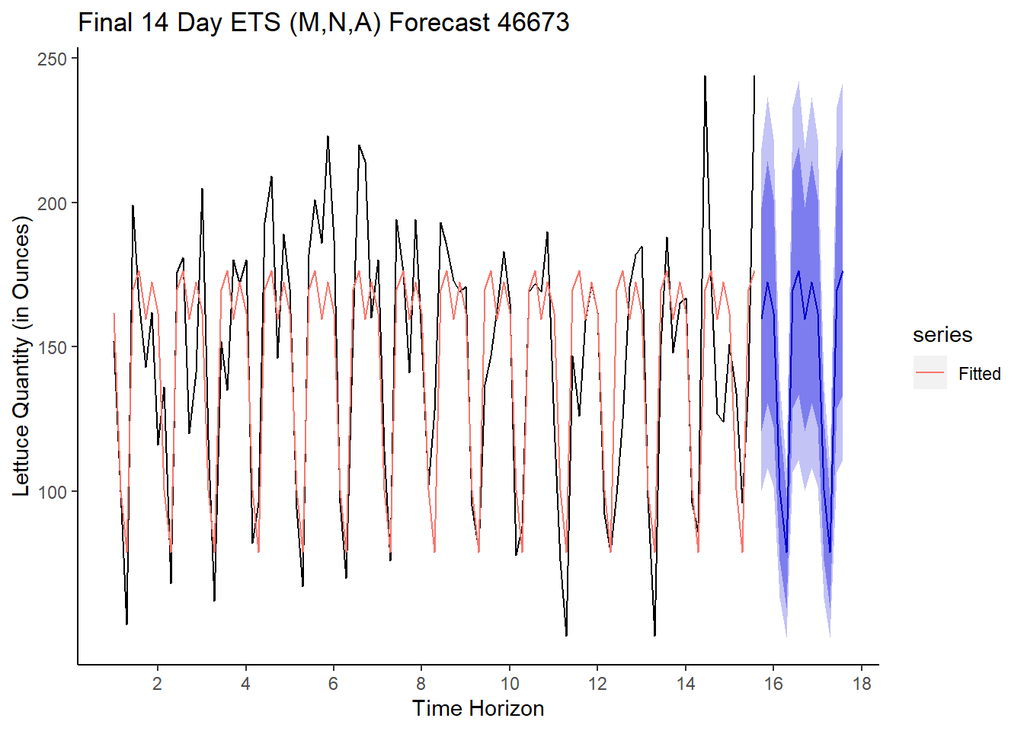

```r
autoplot(final_ets_store_46673, main = 'Final 14 Day ETS (M,N,A) Forecast 46673',
         ylab = 'Lettuce Quantity (in Ounces)', xlab = 'Time Horizon') +
  autolayer(fitted(final_ets_store_46673), series = 'Fitted', na.rm=TRUE) +
  scale_x_continuous(breaks = seq(0, 22, by = 2)) +
  theme(panel.grid.major = element_blank(), panel.grid.minor = element_blank(),
        panel.background = element_blank(), axis.line = element_line(colour = "black")) +
  scale_y_continuous(breaks = c(100, 150, 200, 250, 300, 350, 400, 450, 500, 550))
```

### Forecast Further Improvements

The autocorrelation plot (ACF)is a visual way to show serial correlation in data that changes over time and will be the final test used to see if the residuals are white noise. The plot goes hand in hand with the Ljung-Box test. Using ggplots, ggACF() function, lags 1 - 19 are visually displayed. Autocorrelation is where an error at one point in time travels to a subsequent point in time. The blue lines are based on the sampling distribution for autocorrelation assuming the data is white noise. Any spike between the blue lines should be ignored as they are not statistically significant. Spikes out of the blue lines might indicate something interesting in the data that could be used to build a forecasting analysis. Obsebserving this ACF plot allows us to see that only one lag (lag = 11) is significant as it touches the blue lines. Out of the first 20 lags, one is expected to exceed the 95% confidence interval marked by the blue lines, and one lag does just that and this is attributed to randomness.

```r
## Ljung-Box Test
Box.test(final_ets_store_46673$residuals, lag = 20, type = 'Ljung-Box')
```

```
##
##  Box-Ljung test
##
## data:  final_ets_store_46673$residuals
## X-squared = 22.623, df = 20, p-value = 0.3077
```

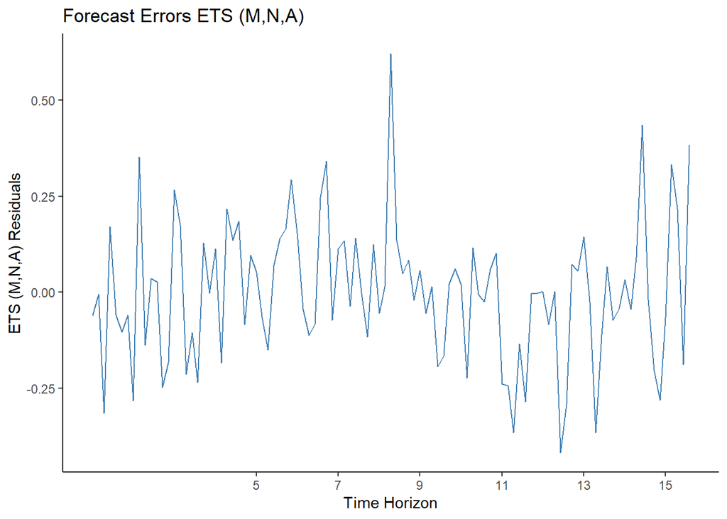

```r
## These plots are descriptive but they can be improved to increase interpretability by plotting and optimising each one individually
## Lets focus on the residuals plot in order to determine if they have constant variance (desired)
autoplot(final_ets_store_46673$residuals, main = 'Forecast Errors ETS (M,N,A)', ylab = 'ETS (M,N,A) Residuals',
         xlab = 'Time Horizon', col = 'steelblue') +
  scale_x_continuous(breaks = seq(5, 22, by = 2)) +
  theme(panel.grid.major = element_blank(), panel.grid.minor = element_blank(), panel.background = element_blank(), axis.line = element_line(colour = "black"))
```

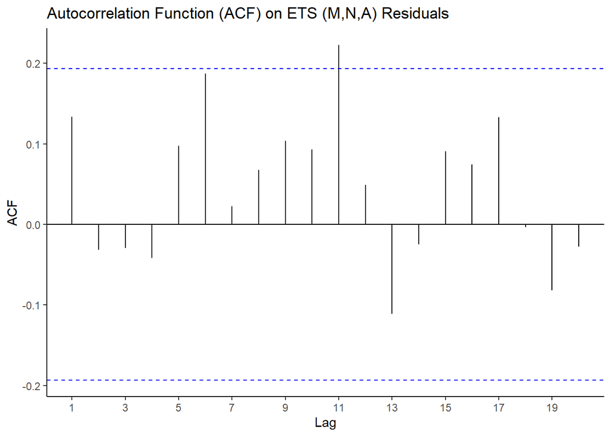

```r
## Next lets look at the ACF plot
ggAcf(final_ets_store_46673$residuals, main = 'Autocorrelation Function (ACF) on ETS (M,N,A) Residuals') +
  theme(panel.grid.major = element_blank(), panel.grid.minor = element_blank(), panel.background = element_blank(), axis.line = element_line(colour = "black")) +
  scale_x_continuous(breaks = seq(1, 22, by = 2))
```

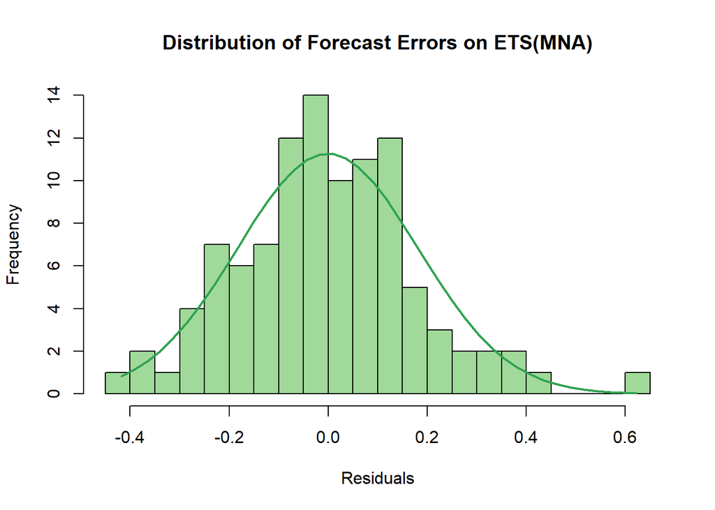

```r
## Histogram of residuals
h <- hist(final_ets_store_46673$residuals, breaks = 20, col = '#a1d99b', main = 'Distribution of Forecast Errors on ETS(MNA)', xlab = 'Residuals')
xfit<-seq(min(final_ets_store_46673$residuals),max(final_ets_store_46673$residuals),length=40)
yfit<-dnorm(xfit,mean=mean(final_ets_store_46673$residuals),sd=sd(final_ets_store_46673$residuals))
yfit <- yfit*diff(h$mids[1:2])*length(final_ets_store_46673$residuals)
lines(xfit, yfit, col="#31a354", lwd=2)
```

The four tests above help conclude that the ETS(MNA) model is an suficient predictive model with no possible further improvments when trying to predict the lettuce demand for store number 46673.

### ARIMA Forecast Models

The next step in the project is to develop and ARIMA model that is able to forecast lettuce demand. The ARIMA model will then be compared with the final ETS model above to determine what the truest and most accurate forecast model is.

The outlined tests are completed below in order to determine any trends that might or might not have to be taken into account in the ARIMA model.

```r
## Arima for store 46673
## Testing if timeseries of store is stationary
adf.test(ts_store_46673) ## Augmented Dickey–Fuller (ADF) t-statistic test to find if the series has a unit root (a series with a trend line will have a unit root and result in a large p-value)
```

```
##
##  Augmented Dickey-Fuller Test
##
## data:  ts_store_46673
## Dickey-Fuller = -8.4973, Lag order = 4, p-value = 0.01
## alternative hypothesis: stationary
```

```r
kpss.test(ts_store_46673, null = 'Trend') ## Kwiatkowski-Phillips-Schmidt-Shin (KPSS) tests he null hypothesis of trend stationarity (a low p-value will indicate a signal that is not trend stationary, has a unit root)
```

```
##
##  KPSS Test for Trend Stationarity
##
## data:  ts_store_46673
## KPSS Trend = 0.10896, Truncation lag parameter = 4, p-value = 0.1
```

```r
ndiffs(ts_store_46673)
```

```
## [1] 0
```

```r
nsdiffs(ts_store_46673)
```

```
## [1] 1
```

```r
pp.test(ts_store_46673)
```

```
##
##  Phillips-Perron Unit Root Test
##
## data:  ts_store_46673
## Dickey-Fuller Z(alpha) = -55.097, Truncation lag parameter = 4, p-value
## = 0.01
## alternative hypothesis: stationary
```

[figure not shown]

```r
## Next lets look at the ACF plot for the differences
ggAcf(ts_store_46673, main = 'Autocorrelation Function (ACF) of Seasonal Differenced Time-Series') +
  theme(panel.grid.major = element_blank(), panel.grid.minor = element_blank(), panel.background = element_blank(), axis.line = element_line(colour = "black")) +
  scale_x_continuous(breaks = seq(1, 100, by = 2))
```

[figure not shown]

```r
## The partial autocorrelation function gives the partial correlation of a stationary time series with its own lagged values, regressed the values of the time series at all shorter lags. It contrasts with the autocorrelation function, which does not control for other lags.
ggPacf(ts_store_46673, main = 'Partial Autocorrelation Function (PACF) of Seasonal Differenced Time-Series') +
  theme(panel.grid.major = element_blank(), panel.grid.minor = element_blank(), panel.background = element_blank(), axis.line = element_line(colour = "black")) +
  scale_x_continuous(breaks = seq(1, 100, by = 2))
```

```r
## Initial auto.arima model that finds 'best model'
auto.arima(ts_store_46673, trace = TRUE, ic = 'bic') ## Best model is determined to be: Best model: ARIMA(0,0,0)(2,1,0)[7] log likelihood=-464.12
```

```
##
##  ARIMA(2,0,2)(1,1,1)[7] with drift         : Inf
##  ARIMA(0,0,0)(0,1,0)[7] with drift         : 964.5852
##  ARIMA(1,0,0)(1,1,0)[7] with drift         : 952.5099
##  ARIMA(0,0,1)(0,1,1)[7] with drift         : Inf
##  ARIMA(0,0,0)(0,1,0)[7]                    : 960.033
##  ARIMA(1,0,0)(0,1,0)[7] with drift         : 969.0862
##  ARIMA(1,0,0)(2,1,0)[7] with drift         : 948.1129
##  ARIMA(1,0,0)(2,1,1)[7] with drift         : Inf
##  ARIMA(1,0,0)(1,1,1)[7] with drift         : Inf
##  ARIMA(0,0,0)(2,1,0)[7] with drift         : 946.2993
##  ARIMA(0,0,0)(1,1,0)[7] with drift         : 948.5985
##  ARIMA(0,0,0)(2,1,1)[7] with drift         : Inf
##  ARIMA(0,0,0)(1,1,1)[7] with drift         : Inf
##  ARIMA(0,0,1)(2,1,0)[7] with drift         : 947.2248
##  ARIMA(1,0,1)(2,1,0)[7] with drift         : 951.27
##  ARIMA(0,0,0)(2,1,0)[7]                    : 941.9237
##  ARIMA(0,0,0)(1,1,0)[7]                    : 944.1557
##  ARIMA(0,0,0)(2,1,1)[7]                    : Inf
##  ARIMA(0,0,0)(1,1,1)[7]                    : Inf
##  ARIMA(1,0,0)(2,1,0)[7]                    : 943.7616
##  ARIMA(0,0,1)(2,1,0)[7]                    : 942.8872
##  ARIMA(1,0,1)(2,1,0)[7]                    : 946.9357
##
##  Best model: ARIMA(0,0,0)(2,1,0)[7]
```

```
## Series: ts_store_46673
## ARIMA(0,0,0)(2,1,0)[7]
##
## Coefficients:
##          sar1     sar2
##       -0.5887  -0.3022
## s.e.   0.1038   0.1119
##
## sigma^2 estimated as 917.5:  log likelihood=-464.12
## AIC=934.23   AICc=934.49   BIC=941.92
```

```r
## AIC=934.23   AICc=934.49   BIC=941.92
```

### Manual ARIMA Functions

All the tests above, along with the best model of the auto.arima() should be a possible form or variation of ARIMA(p,0,q)(P,1,Q). The section below tests variations of the possible base form.

```r
## Testing various Arima models using lambda = 0 to estimate log data
arima1_store_46673 <- Arima(ts_store_46673, order = c(1, 0, 0), seasonal = list(order = c (1, 1, 0), period = 7), include.drift = TRUE)
arima2_store_46673 <- Arima(ts_store_46673, order = c(1, 0, 0), seasonal = list(order = c (2, 1, 0), period = 7), include.drift = TRUE)
arima3_store_46673 <- Arima(ts_store_46673, order = c(0, 0, 0), seasonal = list(order = c (2, 1, 0), period = 7), include.drift = TRUE)
arima4_store_46673 <- Arima(ts_store_46673, order = c(0, 0, 0), seasonal = list(order = c (2, 1, 0), period = 7), include.drift = TRUE)
arima5_store_46673 <- Arima(ts_store_46673, order = c(0, 0, 0), seasonal = list(order = c (1, 0, 0), period = 7))
arima6_store_46673 <- Arima(ts_store_46673, order = c(1, 0, 0), seasonal = list(order = c (3, 0, 0), period = 7))
arima7_store_46673 <- Arima(ts_store_46673, order = c(1, 0, 0), seasonal = list(order = c (2, 0, 0), period = 7))
arima8_store_46673 <- Arima(ts_store_46673, order = c(1, 0, 0), seasonal = list(order = c (2, 0, 1), period = 7))
arima9_store_46673 <- Arima(ts_store_46673, order = c(1, 0, 0), seasonal = list(order = c (4, 0, 0), period = 7))
arima10_store_46673 <- Arima(ts_store_46673, order = c(1, 0, 1), seasonal = list(order = c (1, 0, 2), period = 7))
arima11_store_46673 <- Arima(ts_store_46673, order = c(0, 1, 1), seasonal = list(order = c (1, 0, 3), period = 7))
arima12_store_46673 <- Arima(ts_store_46673, order = c(1, 1, 1), seasonal = list(order = c (1, 0, 1), period = 7))
```

The forecast function is used on each ARIMA model and used with a 14 number period forecast.

```r
## Forecast
forecast_arima1_store46673 <- forecast(arima1_store_46673, h = 14)
forecast_arima2_store46673 <- forecast(arima2_store_46673, h = 14)
forecast_arima3_store46673 <- forecast(arima3_store_46673, h = 14)
forecast_arima4_store46673 <- forecast(arima4_store_46673, h = 14)
forecast_arima5_store46673 <- forecast(arima5_store_46673, h = 14)
forecast_arima6_store46673 <- forecast(arima6_store_46673, h = 14)
forecast_arima7_store46673 <- forecast(arima7_store_46673, h = 14)
forecast_arima8_store46673 <- forecast(arima8_store_46673, h = 14)
forecast_arima9_store46673 <- forecast(arima9_store_46673, h = 14)
forecast_arima10_store46673 <- forecast(arima10_store_46673, h = 14)
forecast_arima11_store46673 <- forecast(arima11_store_46673, h = 14)
forecast_arima12_store46673 <- forecast(arima12_store_46673, h = 14)
```

### In-Sample Comparison

The performance metric used for evaluation is the RMSE. By looking at the results of each one, the lowest RMSE is from ARIMA12 (26.16), while ARIMA10 and ARIMA8 are next two best with RMSE scores of 26.36 and 26.38 respectively. The best three ARIMA models will be improved and visually displayed.

```r
## Accuracy stores Training Sets
accuracy_arima_46673 <- rbind(accuracy(forecast_arima1_store46673), accuracy(forecast_arima2_store46673), accuracy(forecast_arima3_store46673),
           accuracy(forecast_arima4_store46673), accuracy(forecast_arima5_store46673), accuracy(forecast_arima6_store46673),
           accuracy(forecast_arima7_store46673), accuracy(forecast_arima8_store46673), accuracy(forecast_arima9_store46673),
           accuracy(forecast_arima10_store46673), accuracy(forecast_arima11_store46673), accuracy(forecast_arima12_store46673))

accuracy_arima_46673_k <- data.frame(accuracy_arima_46673,
                                     row.names = c('ARIMA(1,0,0)(1,1,0)', 'ARIMA(1,0,0)(2,1,0)', 'ARIMA(0,0,0)(2,1,0)',
                                                   'ARIMA(2,0,0)(2,1,0)', 'ARIMA(0,0,0)(1,0,0)', 'ARIMA(1,0,0)(3,0,0)',
                                                   'ARIMA(1,0,0)(2,0,0)', 'ARIMA(2,0,0)(2,0,1)', 'ARIMA(1,0,0)(4,0,0)',
                                                   'ARIMA(1,0,1)(1,0,2)','ARIMA(1,1,0)(1,0,3)','ARIMA(1,1,1)(1,0,1)'))

accuracy_arima_46673_k %>%  kable(caption = "Accuracy of ARIMA1 Model", align = 'c') %>%  kable_styling(full_width = F)
```

Accuracy of ARIMA1 Model

[output not shown]

[figure not shown]

```r
## Plotting the best three models (lowest training set RMSE)
autoplot(ts_store_46673) +
  autolayer(fitted(forecast_arima10_store46673), series = 'ARIMA(1,1,1)(1,0,1)', na.rm=TRUE, linetype = "dashed") +
  autolayer(fitted(forecast_arima8_store46673), series = 'ARIMA(2,0,0)(2,0,1)', na.rm=TRUE, linetype = 'dashed') +
  autolayer(fitted(forecast_arima12_store46673), series = 'ARIMA(1,0,1)(1,0,2)', na.rm=TRUE, linetype = "dashed") +
  scale_color_manual(values = c('#7fc97f' ,'#beaed4', '#fdc086')) +
  theme(panel.grid.major = element_blank(), panel.grid.minor = element_blank(), panel.background = element_blank(), axis.line = element_line(colour = "black"))
```

### Creating, Forecasting and Visualizing ARIMA(p,d,q)(P,0,Q) on Training Set

Following the same Training-Test Set approach introduced in the computations of the Exponential Smoothing models, the in-sample and out-of-sample performance of the above ARIMA models need to be compared in order to find the best one that best fits. More specifically, every model is trained on the Training set (first 83 days of time-series, 80% of the entire time series for store number 46673) then predicts the demand for the next 20 days. The evaluation of the predictions is based on the Test set (last 20 days of initial time-series, 20% of the entire time series for store number 46673) and based on those values the forecast errors of each model are computed.

```r
## Train best models on training set
training_arima8_store_46673 <- Arima(training_ts_store_46673, order = c(1, 0, 0), seasonal = list(order = c (2, 0, 1), period = 7))
training_arima10_store_46673 <- Arima(training_ts_store_46673, order = c(1, 0, 1), seasonal = list(order = c (1, 0, 2), period = 7))
training_arima12_store_46673 <- Arima(training_ts_store_46673, order = c(1, 1, 1), seasonal = list(order = c (1, 0, 1), period = 7))

## Forecast using the best models
forecast_arima8_store46673 <- forecast(training_arima8_store_46673, h = 20)
forecast_arima10_store46673 <- forecast(training_arima10_store_46673, h = 20)
forecast_arima12_store46673 <- forecast(training_arima12_store_46673, h = 20)

accuracy_final_arima_46673 <- rbind(accuracy(forecast_arima8_store46673, test_ts_store_46673),
                              accuracy(forecast_arima10_store46673, test_ts_store_46673),
                              accuracy(forecast_arima12_store46673, test_ts_store_46673))

accuracy_final_arima_46673_k <- data.frame(accuracy_final_arima_46673, row.names = c('Train', 'Test', 'Train_2', 'Test_2', 'Train_3', 'Test_3'))

accuracy_final_arima_46673_k %>%  kable(caption = "Accuracy of ARIMA Model", align = 'c') %>%  kable_styling(full_width = F) %>%
  pack_rows("ARIMA(1,1,1)(1,0,1)", 1, 2) %>%
  pack_rows("ARIMA(2,0,0)(2,0,1)", 3, 4) %>%
  pack_rows("ARIMA(1,0,1)(1,0,2))", 5, 6)
```

Accuracy of ARIMA Model

[output not shown]

### Final ARIMA Model

The best ARIMA model is trained once again on the entire time series of store 46673 in order to provide the most accurate forecast for the 14 day lettuce demand. The model final forecast for the lettuce demand using the ARIMA(1, 0, 0)(2, 0, 1)[7] is modeled below.

```r
## Train best model on the entire dataset from store 46673]
best_arima8_store_46673 <- Arima(ts_store_46673, order = c(1, 0, 0), seasonal = list(order = c (2, 0, 1), period = 7))
forecast_best_arima_store_46673 <- forecast(best_arima8_store_46673, h = 14)

## Best model table
forecast_best_arima_store_46673_k <- data.frame(forecast_best_arima_store_46673,
                                                row.names = c('16/06/15', '17/06/15', '18/06/15', '19/06/15', '20/06/15', '21/06/15',
                                                              '22/06/15', '23/06/15', '24/06/15', '25/06/15', '26/06/15', '27/06/15',
                                                              '28/06/15', '29/06/15'))
forecast_best_arima_store_46673_k %>%  kable(caption = "Final 14 Day ARIMA Forecast", align = 'c') %>%  kable_styling(full_width = F)
```

Final 14 Day ARIMA Forecast

|  | Point.Forecast | Lo.80 | Hi.80 | Lo.95 | Hi.95 |
| --- | --- | --- | --- | --- | --- |
| 16/06/15 | 170.60609 | 135.20576 | 206.0064 | 116.46595 | 224.7462 |
| 17/06/15 | 172.44675 | 136.55218 | 208.3413 | 117.55075 | 227.3427 |
| 18/06/15 | 163.61884 | 127.77738 | 199.4603 | 108.80406 | 218.4336 |
| 19/06/15 | 103.48612 | 67.64428 | 139.3280 | 48.67075 | 158.3015 |
| 20/06/15 | 79.87342 | 44.03157 | 115.7153 | 25.05803 | 134.6888 |
| 21/06/15 | 166.75030 | 130.90844 | 202.5922 | 111.93491 | 221.5657 |
| 22/06/15 | 177.52870 | 141.68684 | 213.3706 | 122.71331 | 232.3441 |
| 23/06/15 | 160.35700 | 124.35330 | 196.3607 | 105.29409 | 215.4199 |
| 24/06/15 | 171.91439 | 135.90812 | 207.9207 | 116.84755 | 226.9812 |
| 25/06/15 | 163.65657 | 127.72091 | 199.5922 | 108.69773 | 218.6154 |
| 26/06/15 | 102.55448 | 66.61882 | 138.4901 | 47.59564 | 157.5133 |
| 27/06/15 | 79.41034 | 43.47468 | 115.3460 | 24.45149 | 134.3692 |
| 28/06/15 | 167.57928 | 131.64362 | 203.5149 | 112.62043 | 222.5381 |
| 29/06/15 | 175.59052 | 139.65486 | 211.5262 | 120.63168 | 230.5494 |

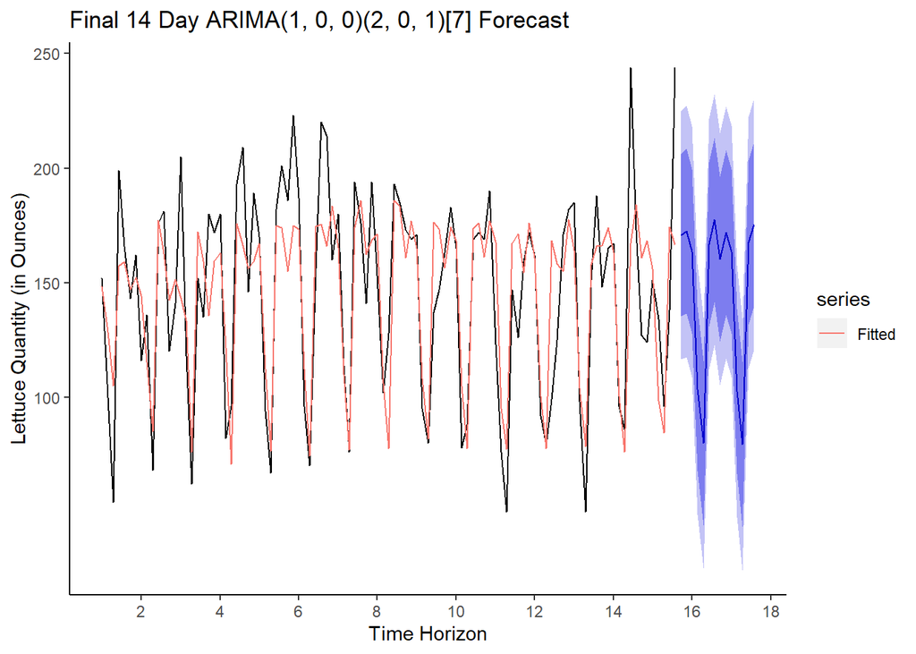

```r
## Best model plotted
autoplot(forecast_best_arima_store_46673, main = 'Final 14 Day ARIMA(1, 0, 0)(2, 0, 1)[7] Forecast',
         ylab = 'Lettuce Quantity (in Ounces)', xlab = 'Time Horizon') +
  autolayer(fitted(forecast_best_arima_store_46673), series = 'Fitted', na.rm=TRUE) +
  scale_x_continuous(breaks = seq(0, 22, by = 2)) +
  theme(panel.grid.major = element_blank(), panel.grid.minor = element_blank(), panel.background = element_blank(), axis.line = element_line(colour = "black")) +
  scale_y_continuous(breaks = c(100, 150, 200, 250, 300, 350, 400, 450, 500, 550))
```

### Forecast Further Improvements

The model must be checked by a residual analysis to see for further improvements. Much like the ETS model, there needs to be no correlations between the forecast errors of the model in the time series.

The Ljung-Box test statistic considers the first “h” autocorrelations values together. A significant test (small p-value) indicates the data are probably not white noise. The test is perfomed on lags 1 - 20 and the the null hypothesis is the independence of the time series. The Box.test() results in a test statistic of 17.58 and a p-value of 0.6151. These are large values and the null hypotheisis of indipenditely distributed forecast errors is accepted.

Using ggplots, ggACF() function, lags 1 - 19 are visually displayed.Obsebserving this ACF plot allows us to see that only one lag (lag = 6) is significant and that can be exaplained by randomness as one of the first 20 lags can exceed the bounds by chance only. Therefore it can be concluded that that there is no serial autocorrelation between lags 1-19.

```r
## Ljung-Box Test
Box.test(forecast_best_arima_store_46673$residuals, lag = 20, type = 'Ljung-Box')
```

```
##
##  Box-Ljung test
##
## data:  forecast_best_arima_store_46673$residuals
## X-squared = 17.58, df = 20, p-value = 0.6151
```

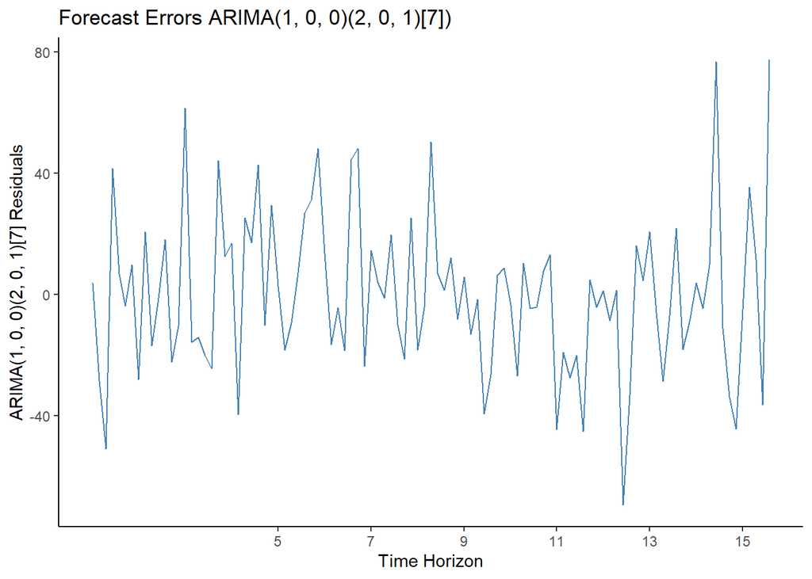

```r
## These plots are descriptive but they can be improved to increase interpretability by plotting and optimising each one individually
## Lets focus on the residuals plot in order to determine if they have constant variance (desired)
autoplot(forecast_best_arima_store_46673$residuals, main = 'Forecast Errors ARIMA(1, 0, 0)(2, 0, 1)[7])', xlab = 'Time Horizon',
         ylab = 'ARIMA(1, 0, 0)(2, 0, 1)[7] Residuals', col = 'steelblue') +
  scale_x_continuous(breaks = seq(5, 22, by = 2)) +
  theme(panel.grid.major = element_blank(), panel.grid.minor = element_blank(), panel.background = element_blank(),
        axis.line = element_line(colour = "black"))
```

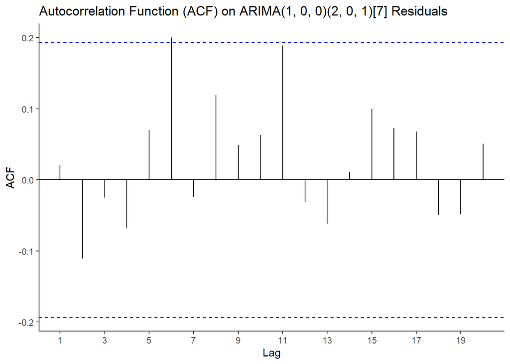

```r
## Next lets look at the ACF plot
ggAcf(forecast_best_arima_store_46673$residuals, main = 'Autocorrelation Function (ACF) on ARIMA(1, 0, 0)(2, 0, 1)[7] Residuals') +
  theme(panel.grid.major = element_blank(), panel.grid.minor = element_blank(), panel.background = element_blank(),
        axis.line = element_line(colour = "black")) +
  scale_x_continuous(breaks = seq(1, 100, by = 2))
```

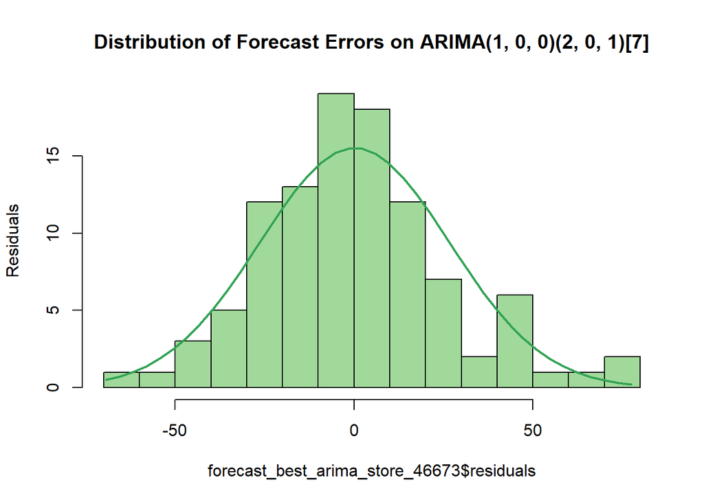

```r
## Histogram
h <- hist(forecast_best_arima_store_46673$residuals, breaks = 20, col = '#a1d99b',
          main = 'Distribution of Forecast Errors on ARIMA(1, 0, 0)(2, 0, 1)[7]', ylab = 'Residuals')
xfit<-seq(min(forecast_best_arima_store_46673$residuals),max(forecast_best_arima_store_46673$residuals),length=40)
yfit<-dnorm(xfit,mean=mean(forecast_best_arima_store_46673$residuals),sd=sd(forecast_best_arima_store_46673$residuals))
yfit <- yfit*diff(h$mids[1:2])*length(forecast_best_arima_store_46673$residuals)
lines(xfit, yfit, col="#31a354", lwd=2)
```

The plotted residuals and the histogram show that the forecast errors have constant variance over time and are normally distributed with mean of zero. It is conclusive that ARIMA(1, 0, 0)(2, 0, 1)[7] provides an adequate preditive model for the lettuce demand of store 46673.

### Final Forecast for Resturant 46673: ETS(M,N,A) vs. ARIMA(1, 0, 0)(2, 0, 1)[7]

The models are now compared against eachother below and the model with the lowest RMSE will be determined the best model for lettuce demand forecasting for store 46673.

```r
## Checking which model based on RMSE (ETS or ARIMA)
accuracy_final_model_all_46673 <- rbind(accuracy(forecast_ets_store_46673, test_ts_store_46673),
                              accuracy(forecast_arima8_store46673, test_ts_store_46673))

accuracy_final_model_all_46673_k <- data.frame(accuracy_final_model_all_46673, row.names = c('Train', 'Test', 'Train_2', 'Test_2'))

accuracy_final_model_all_46673_k %>%  kable(caption = "Accuracy of Best ETS and ARIMA", align = 'c') %>%  kable_styling(full_width = F) %>%
  pack_rows("ETS(M,N,A)", 1, 2) %>%
  pack_rows("ARIMA(1,0,0)(2,0,1)", 3, 4)
```

Accuracy of Best ETS and ARIMA

|  | ME | RMSE | MAE | MPE | MAPE | MASE | ACF1 |
| --- | --- | --- | --- | --- | --- | --- | --- |
| **ETS(M,N,A)** |  |  |  |  |  |  |  |
| Train | -1.4182470 | 23.57966 | 18.68909 | -4.407552 | 14.48863 | 0.4394910 | 0.1213830 |
| Test | 12.4672459 | 33.47771 | 24.53264 | 5.219422 | 16.76160 | 0.5769076 | NA |
| **ARIMA(1,0,0)(2,0,1)** |  |  |  |  |  |  |  |
| Train_2 | -0.4036374 | 25.72125 | 20.21825 | -4.715236 | 15.91304 | 0.4754508 | 0.0106491 |
| Test_2 | 14.7295495 | 42.01489 | 28.67797 | 4.428761 | 18.70934 | 0.6743888 | NA |

ETS(M,N,A) appears to fit the data better than the ARIMA model and similarly has better forecasting power than the ARIMA model. This is based on the in-sample (Training set) and out-of-sample (Test set) RMSE scores. It is therefore selected as the final forecast model for store number 46673. It is trained on the entire time series in order to enhance its forecasting power, and made to forecast 14 days.

The final forecast of lettuce demand for store number 46673 from 06/16/2015 to 06/29/2015 is saved on a csv file.

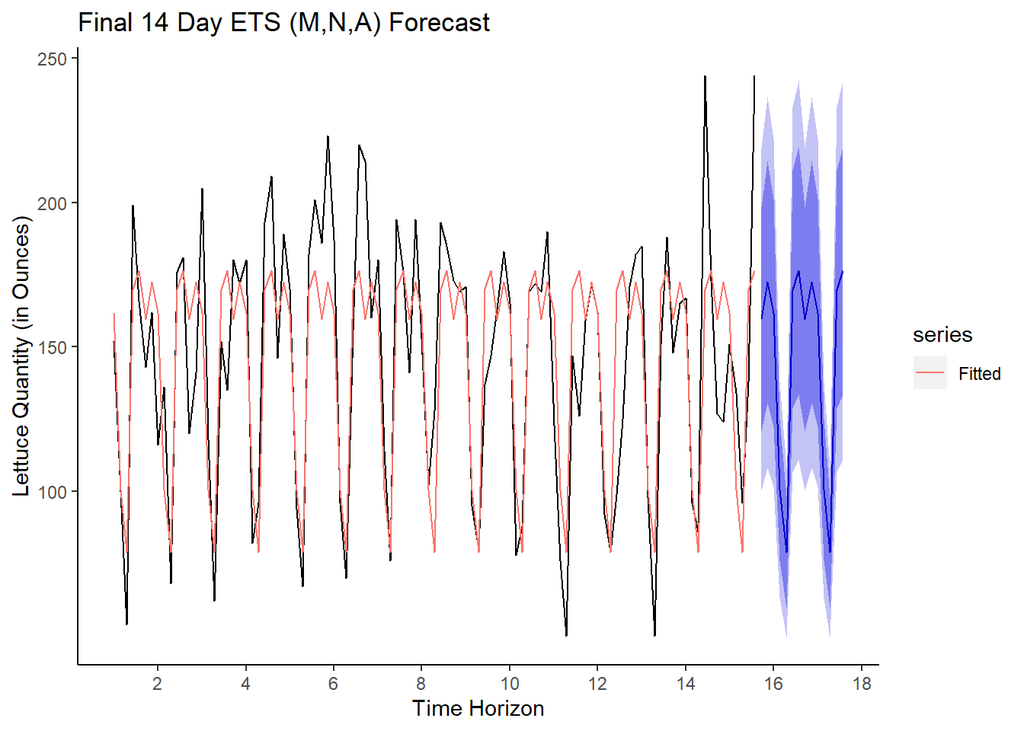

```r
## Final model for store 46673
final_store_46673 <- forecast(ets_store_46673, h = 14)
autoplot(final_store_46673, main = 'Final 14 Day ETS (M,N,A) Forecast', ylab = 'Lettuce Quantity (in Ounces)', xlab = 'Time Horizon', xlab = 'Time Horizon') +
  autolayer(fitted(final_store_46673), series = 'Fitted', na.rm=TRUE) +
  scale_x_continuous(breaks = seq(0, 22, by = 2)) +
  theme(panel.grid.major = element_blank(), panel.grid.minor = element_blank(), panel.background = element_blank(), axis.line = element_line(colour = "black")) +
  scale_y_continuous(breaks = c(100, 150, 200, 250, 300, 350, 400, 450, 500, 550))
```

```r
## Forecast results to csv
write.csv(final_store_46673, 'store_46673_forecast.csv')

## Final Forecast (Table)
final_store_46673_k <- data.frame(final_store_46673, row.names = c('16/06/15', '17/06/15', '18/06/15', '19/06/15', '20/06/15', '21/06/15', '22/06/15', '23/06/15', '24/06/15', '25/06/15', '26/06/15', '27/06/15', '28/06/15', '29/06/15'))
final_store_46673_k %>%  kable(caption = "Final 14 Day ETS Forecast", align = 'c') %>%  kable_styling(full_width = F)
```

Final 14 Day ETS Forecast

|  | Point.Forecast | Lo.80 | Hi.80 | Lo.95 | Hi.95 |
| --- | --- | --- | --- | --- | --- |
| 16/06/15 | 159.54815 | 120.73789 | 198.35842 | 100.19297 | 218.9033 |
| 17/06/15 | 172.45762 | 130.50711 | 214.40813 | 108.29985 | 236.6154 |
| 18/06/15 | 161.76594 | 122.41619 | 201.11568 | 101.58570 | 221.9462 |
| 19/06/15 | 100.50529 | 76.05727 | 124.95332 | 63.11526 | 137.8953 |
| 20/06/15 | 78.87924 | 59.69178 | 98.06671 | 49.53455 | 108.2239 |
| 21/06/15 | 169.94661 | 128.60691 | 211.28631 | 106.72299 | 233.1702 |
| 22/06/15 | 176.33227 | 133.43925 | 219.22530 | 110.73305 | 241.9315 |
| 23/06/15 | 159.54815 | 120.73788 | 198.35842 | 100.19297 | 218.9033 |
| 24/06/15 | 172.45762 | 130.50711 | 214.40813 | 108.29985 | 236.6154 |
| 25/06/15 | 161.76594 | 122.41619 | 201.11569 | 101.58569 | 221.9462 |
| 26/06/15 | 100.50529 | 76.05727 | 124.95332 | 63.11526 | 137.8953 |
| 27/06/15 | 78.87924 | 59.69177 | 98.06671 | 49.53454 | 108.2239 |
| 28/06/15 | 169.94661 | 128.60690 | 211.28631 | 106.72298 | 233.1702 |
| 29/06/15 | 176.33227 | 133.43925 | 219.22530 | 110.73305 | 241.9315 |

## Resturant 20974: New York, New York

The dataframe created for StoreNumber 20974 has two columns, a date column and a lettuce quantity column. This type of dataframe can be converted into a time series object in R using the ts() function. A timeseries is a series of data points ordered in time. In a time series, time is often the independent variable and the goal is usually to make a forecast for the future, exactly what we are trying to do here. The ts() function converts a numeric vector into a R time series object.

The time-series object of restaurant 20974 is created with a weekly frequency (frequency = 7) and starting and ending day “20-03-2015” and “15-06-2015” respectively. The initial days, “06,10,13,16,17,18-03-2015” were deleted from the time series since sequential missing data occurred or there were some odd trends in the data. The reason of omitting the missing data at the very beginning of the time series is the biased estimation that its presence will cause. By deleteing this data we improve the forecast power available to us.

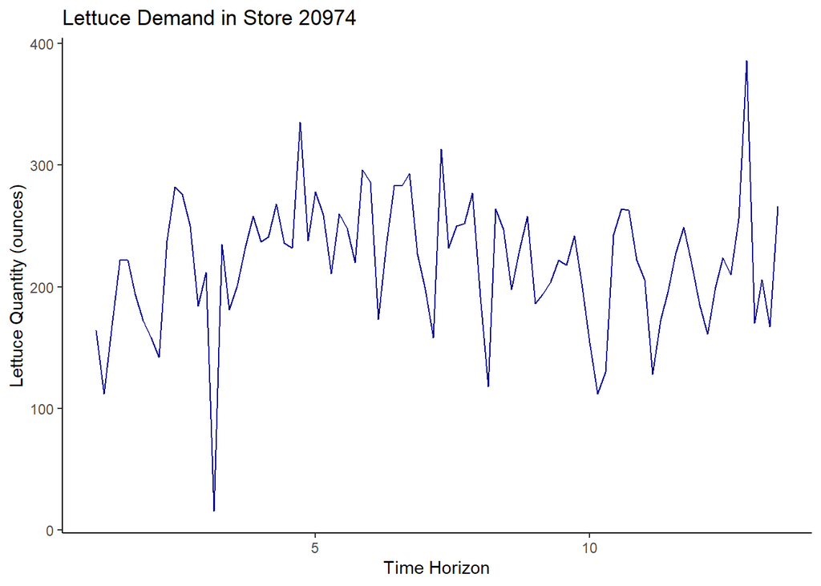

```r
## Remove first 6 days in store dataframe as quanitites look wrong/erreanous
store_20974_cleaned <- store_20974[-c(1:6),]

## Store 20974
ts_store_20974 <- ts(store_20974_cleaned[, 2], frequency = 7, start (03, 05))
autoplot(ts_store_20974,  main="Lettuce Demand in Store 20974 ", xlab="Time Horizon", ylab="Lettuce Quantity (ounces)",
         col = "darkblue", frame.plot = FALSE)  +
  theme(panel.grid.major = element_blank(), panel.grid.minor = element_blank(), panel.background = element_blank(), axis.line = element_line(colour = "black"))
```

### STL Decomposition and Visualisation

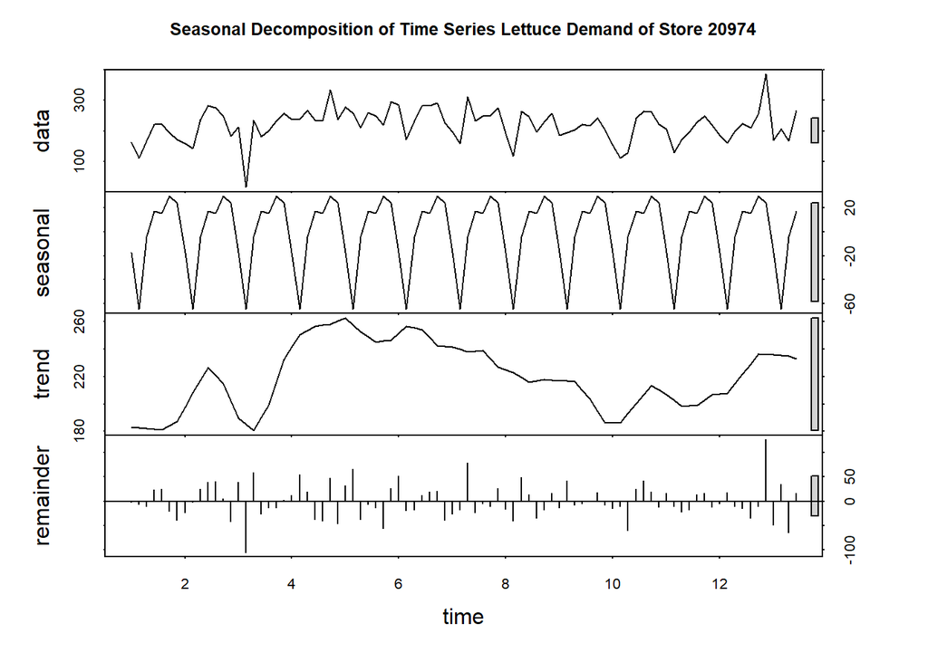

```r
## Seasonal Decompsotion of Time Series
plot(stl(ts_store_20974, s.window = "period"), main="Seasonal Decomposition of Time Series Lettuce Demand of Store 20974", xaxt = 'n')
```

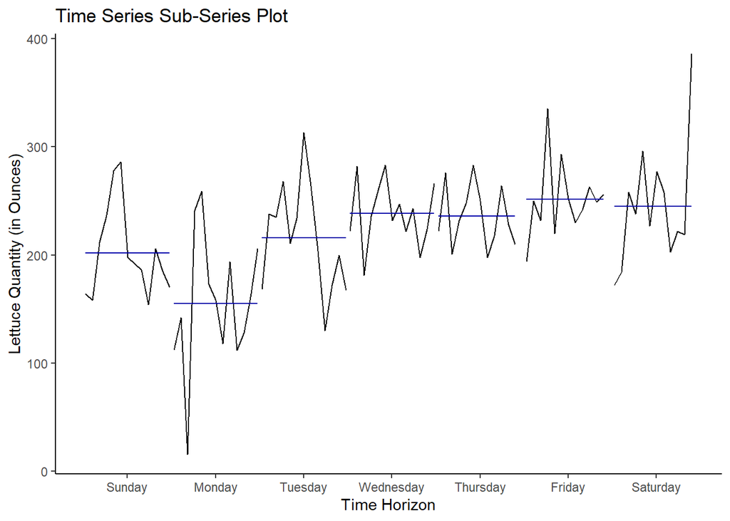

```r
ggsubseriesplot(ts_store_20974, main = 'Time Series Sub-Series Plot', ylab = 'Lettuce Quantity (in Ounces)',
                xlab = 'Time Horizon') +
  theme(panel.grid.major = element_blank(), panel.grid.minor = element_blank(), panel.background = element_blank(),
        axis.line = element_line(colour = "black"))
```

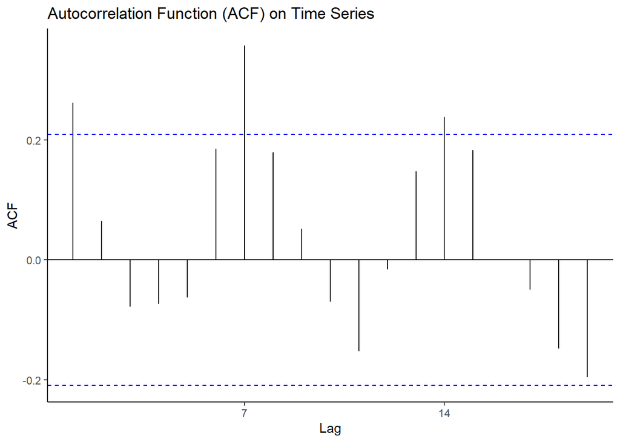

```r
ggAcf(ts_store_20974, main = 'Autocorrelation Function (ACF) on Time Series') +
  theme(panel.grid.major = element_blank(), panel.grid.minor = element_blank(),
        panel.background = element_blank(), axis.line = element_line(colour = "black"))
```

### Initial Holt-Winters and ETS Functions

Initially, a “ZZZ” model is created in order to have R automatically fit the Error, Trend and Seasonality values of the time series. This initial model will return letters which will be used throughout the remaineder of the sotre numbher 20974 forecast process.

The Holt-Winters model, the fitted ETS model and the actual time series are plotted for visual interpretability.

```r
## HoltWinters - ETS
HW_store_20974 <- HoltWinters(ts_store_20974, beta = FALSE)

ets_store_20974 <- ets(ts_store_20974, model = 'ZZZ')
ets_store_20974 ## Automatic model concludes a A,N,A model is best for this data
```

```
## ETS(A,N,A)
##
## Call:
##  ets(y = ts_store_20974, model = "ZZZ")
##
##   Smoothing parameters:
##     alpha = 0.1621
##     gamma = 1e-04
##
##   Initial states:
##     l = 198.2123
##     s = 18.3272 32.354 18.3331 17.1014 -2.6053 -64.0054
##            -19.505
##
##   sigma:  44.8587
##
##      AIC     AICc      BIC
## 1073.931 1076.788 1098.704
```

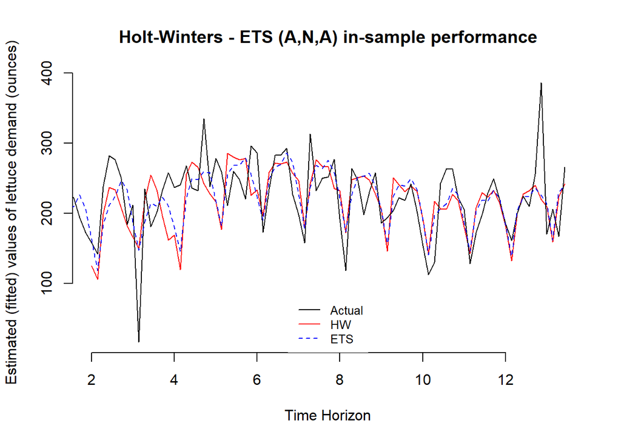

```r
plot(HW_store_20974, main="Holt-Winters - ETS (A,N,A) in-sample performance", xlab="Time Horizon",
     ylab="Estimated (fitted) values of lettuce demand (ounces)", lty = 1, col = "black", frame.plot = FALSE)
lines(fitted(ets_store_20974), col = "blue", lty = 2)
legend("bottom", legend=c("Actual","HW", "ETS"), col=c("black", "red", "blue"), box.lty=0, lty=c(1,1,2), cex=0.8)
```

### Training and Test Set

The test set needs to be the most recent part of the data as the idea is to simulate a production environment, where after the model is trained it would be evaluated on data it had not seen. Throughout this forecasting project an 80:20 split is used. That is, 80% of the time series data will be attributed to the training set and the most recent 20% will be used for the test set.

```r
## Training and Test sets (70 days, 80%)
training_ts_store_20974 <- ts(store_20974_cleaned[1:(nrow(store_20974_cleaned) * 0.8), 2], frequency = 7)
length(training_ts_store_20974)
```

```
## [1] 70
```

```r
## Test set (18 day, 20%)
test_ts_store_20974 <- store_20974_cleaned[((nrow(store_20974_cleaned) * 0.8)) : nrow(store_20974_cleaned)+1, 2]
length(test_ts_store_20974)
```

```
## [1] 18
```

```r
length(test_ts_store_20974) + length(training_ts_store_20974)
```

```
## [1] 88
```

```r
length(test_ts_store_20974) + length(training_ts_store_20974)
```

```
## [1] 88
```

### Creating, Forecasting and Visualizing Holt-Winters on Training Set

The initial Holt-Winters model will now be trained on in-sample data and it will forecast 18 days past the last day of the training data. This is done using the forecast()function which takes the model and a argument, h, the number of periods it should forecast.

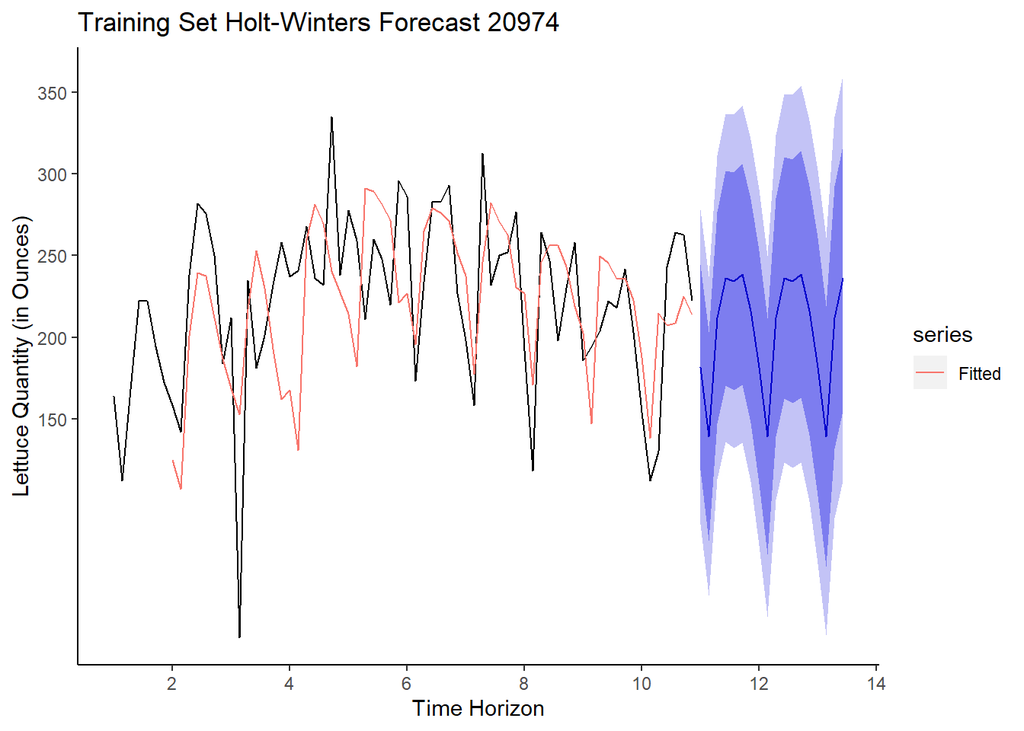

```r
## Creating Holt-Winters filtering of the training time series for store 20974. Beta is set to false to force exponential smoothing
training_HW_store_20974 <- HoltWinters(training_ts_store_20974, beta = FALSE)
forecast_HW1_store_20974 <- forecast(training_HW_store_20974, h = 18)

autoplot(forecast_HW1_store_20974, main = 'Training Set Holt-Winters Forecast 20974',
         ylab = 'Lettuce Quantity (in Ounces)', xlab = 'Time Horizon', xlab = 'Time Horizon') +
  autolayer(fitted(forecast_HW1_store_20974), series = 'Fitted', na.rm=TRUE) +
  scale_x_continuous(breaks = seq(0, 16, by = 2)) +
  scale_y_continuous(breaks = c(150, 200, 250, 300, 350, 400, 450))  +
  theme(panel.grid.major = element_blank(), panel.grid.minor = element_blank(),
        panel.background = element_blank(), axis.line = element_line(colour = "black"))
```

### Creating, Forecasting and Visualizing ETS(ANA) on Training Set

The initial ETS model with a model paramet = ‘ANA’, a model with an additive level and seasonal component, will now be trained on in-sample data and it will forecast 18 days past the last day of the training data. This is done using the forecast()function which takes the model and a argument, h, the number of periods it should forecast.

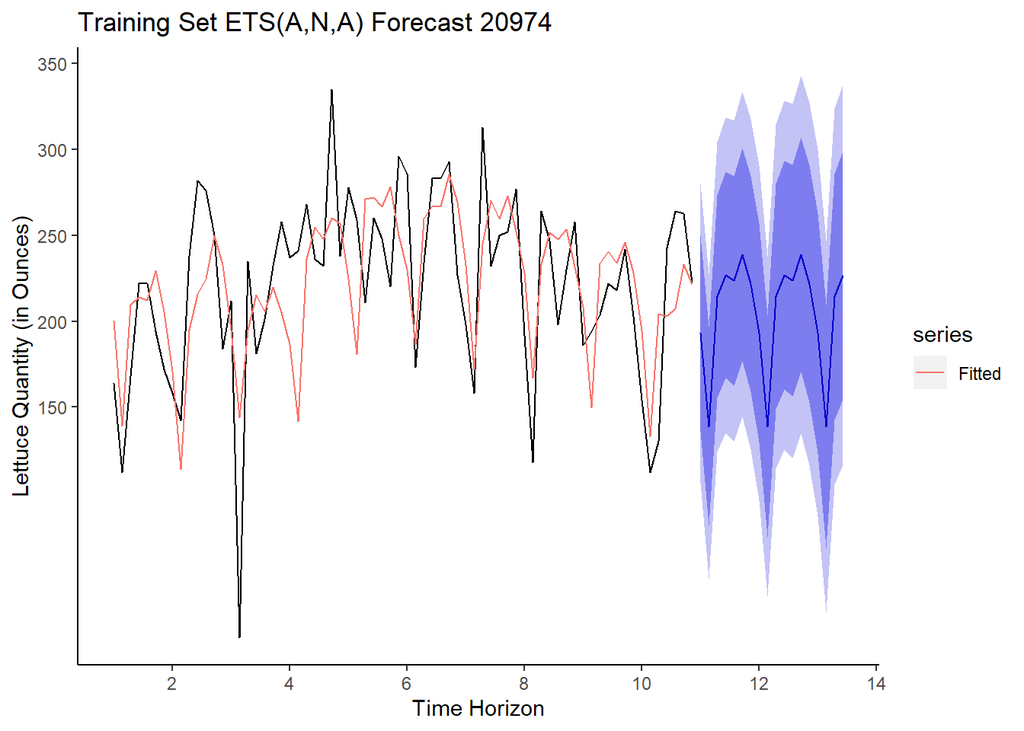

```r
## ## ETS models use maximum likelihood, the probability of the data arising from the specified model. ETS automatically chooses the best type of model. Convenient for forecasting timeseries that have trends or seasonality. Lets explore...
training_ets_store_20974 <- ets(training_ts_store_20974, model = 'ANA')
forecast_ets_store_20974 <- forecast(training_ets_store_20974, h = 18)

autoplot(forecast_ets_store_20974, main = 'Training Set ETS(A,N,A) Forecast 20974',
         ylab = 'Lettuce Quantity (in Ounces)', xlab = 'Time Horizon') +
  autolayer(fitted(forecast_ets_store_20974), series = 'Fitted', na.rm=TRUE) +
  scale_x_continuous(breaks = seq(0, 16, by = 2)) +
  scale_y_continuous(breaks = c(150, 200, 250, 300, 350, 400, 450)) +
  theme(panel.grid.major = element_blank(), panel.grid.minor = element_blank(),
        panel.background = element_blank(), axis.line = element_line(colour = "black"))
```

### Out-Of-Sample Model Comparison

The performance metric used for evaluation is the RMSE. By looking at the results of each accuracy test, it can be concluded that the ETS(ANA) model (RMSE = 47.205) is superior to the Holt-Winters model (RMSE = 48.280) as it has a lower RMSE on the out-of-sample data. The ETS model not only fits the data better, but it also seems to predict it better. Because the ETS model has both a better in-sample and out-of-sample RMSE score and preformance it is selected as the better model and will be tested again later, during the ARIMA forecast process.

```r
## Accuracy Comparison of ETS and Holt-Winter
accuracy_ets_HW_20974 <- rbind(accuracy(forecast_HW1_store_20974, test_ts_store_20974),
                              accuracy(forecast_ets_store_20974, test_ts_store_20974))

accuracy_ets_HW_20974_k <- data.frame(accuracy_ets_HW_20974, row.names = c('Train', 'Test', 'Train_2', 'Test_2'))

accuracy_ets_HW_20974_k %>%  kable(caption = "Accuracy of Best ETS and HW", align = 'c') %>%  kable_styling(full_width = F) %>%
  pack_rows("Holt-Winters", 1, 2) %>%
  pack_rows("ETS(A,N,A)", 3, 4)
```

Accuracy of Best ETS and HW

|  | ME | RMSE | MAE | MPE | MAPE | MASE | ACF1 |
| --- | --- | --- | --- | --- | --- | --- | --- |
| **Holt-Winters** |  |  |  |  |  |  |  |
| Train | 3.3182820 | 48.89555 | 40.60594 | -13.6037851 | 31.06208 | 0.8855278 | 0.1332806 |
| Test | 8.0376420 | 48.28009 | 30.41404 | 0.8726786 | 13.22374 | 0.6632645 | NA |
| **ETS(A,N,A)** |  |  |  |  |  |  |  |
| Train_2 | -0.5314202 | 41.53243 | 34.24962 | -13.4603626 | 26.57567 | 0.7469102 | 0.0831474 |
| Test_2 | 7.9390062 | 47.20564 | 29.52803 | 0.6841513 | 12.93265 | 0.6439426 | NA |

### Final ETS Model

The final ETS(ANA) model is trained on the entire time series relating to store number 20974. This is done in order to give the most accurate 14 day lettuce demand forecast for the store. Again, the forecast() function is used, this time with an “h” argument of 14.

The ETS model and the forecast is presented visually below.

```r
## The ETS model is supieror to the Holt-Winter model because ME, RMSE, MAE, MAPE, and MASE are all lower when comparing the models. The ETS model will be trained on all the data and finally used to forecast the 14 day period (06/16/2015 to 06/29/2015)
final_ets_store_20974 <- forecast(ets_store_20974, h = 14)

final_ets_store_20974_k <- data.frame(final_ets_store_20974,
                                      row.names = c('16/06/15', '17/06/15', '18/06/15', '19/06/15', '20/06/15',
                                                    '21/06/15', '22/06/15', '23/06/15', '24/06/15', '25/06/15',
                                                    '26/06/15', '27/06/15', '28/06/15', '29/06/15'))
final_ets_store_20974_k %>%  kable(caption = "Final 14 Day ETS Forecast", align = 'c') %>%  kable_styling(full_width = F)
```

Final 14 Day ETS Forecast

|  | Point.Forecast | Lo.80 | Hi.80 | Lo.95 | Hi.95 |
| --- | --- | --- | --- | --- | --- |
| 16/06/15 | 245.3543 | 187.86551 | 302.8431 | 157.43279 | 333.2758 |
| 17/06/15 | 259.3771 | 201.13770 | 317.6166 | 170.30761 | 348.4466 |
| 18/06/15 | 245.3595 | 186.37898 | 304.3400 | 155.15658 | 335.5624 |
| 19/06/15 | 207.5218 | 147.80939 | 267.2342 | 116.19955 | 298.8440 |
| 20/06/15 | 163.0179 | 102.58243 | 223.4533 | 70.58984 | 255.4459 |
| 21/06/15 | 224.4164 | 163.26647 | 285.5663 | 130.89565 | 317.9371 |
| 22/06/15 | 244.1267 | 182.26971 | 305.9837 | 149.52459 | 338.7289 |
| 23/06/15 | 245.3543 | 182.79903 | 307.9096 | 149.68427 | 341.0243 |
| 24/06/15 | 259.3771 | 196.13132 | 322.6229 | 162.65102 | 356.1032 |
| 25/06/15 | 245.3595 | 181.43061 | 309.2884 | 147.58870 | 343.1303 |
| 26/06/15 | 207.5218 | 142.91705 | 272.1265 | 108.71737 | 306.3262 |
| 27/06/15 | 163.0179 | 97.74427 | 228.2915 | 63.19051 | 262.8452 |
| 28/06/15 | 224.4164 | 158.48071 | 290.3521 | 123.57647 | 325.2563 |
| 29/06/15 | 244.1267 | 177.53475 | 310.7187 | 142.28309 | 345.9704 |

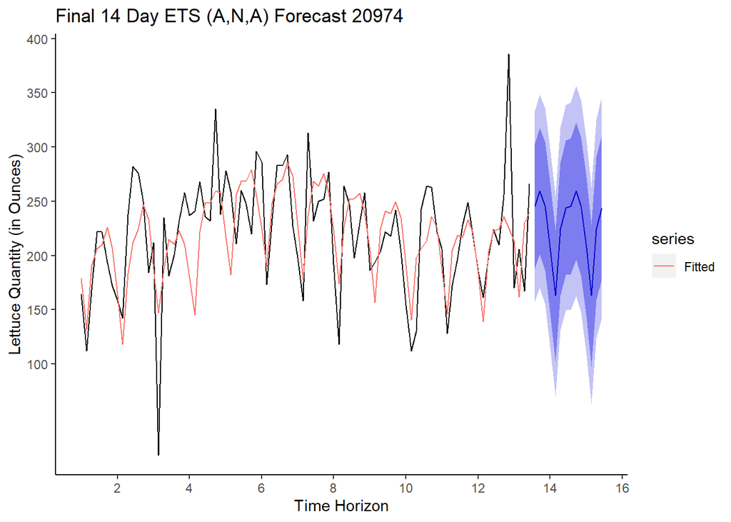

```r
autoplot(final_ets_store_20974, main = 'Final 14 Day ETS (A,N,A) Forecast 20974', ylab = 'Lettuce Quantity (in Ounces)', xlab = 'Time Horizon') +
  autolayer(fitted(final_ets_store_20974), series = 'Fitted', na.rm=TRUE) +
  scale_x_continuous(breaks = seq(0, 22, by = 2)) +
  theme(panel.grid.major = element_blank(), panel.grid.minor = element_blank(), panel.background = element_blank(), axis.line = element_line(colour = "black")) +
  scale_y_continuous(breaks = c(100, 150, 200, 250, 300, 350, 400, 450, 500, 550))
```

### Forecast Further Improvements

From the ACF plot, someone can conclude that there is no serial autocorrelation between at lages 1-20, since all lags are between the significant bounds.

In addition, the forecast errors are tested on whether they are normally distributed with a zero mean and a constant variable. The forecast errors’ constant variance is tested by a time plot of the in-sample forecast errors, whereas their normal distribution with zero mean by a histogram plot of the forecast errors, with an overlaid normal curve that has mean zero and the same standard deviation as the distribution of forecast errors.

```r
## Ljung-Box Test
Box.test(final_ets_store_20974$residuals, lag = 20, type = 'Ljung-Box')
```

```
##
##  Box-Ljung test
##
## data:  final_ets_store_20974$residuals
## X-squared = 12.1, df = 20, p-value = 0.9126
```

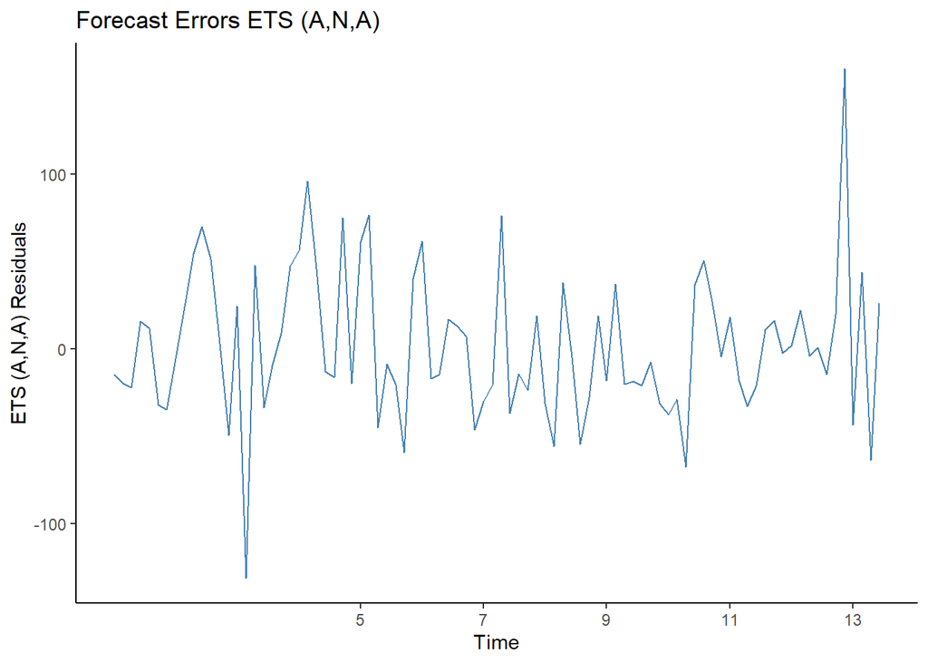

```r
## These plots are descriptive but they can be improved to increase interpretability by plotting and optimising each one individually
## Lets focus on the residuals plot in order to determine if they have constant variance (desired)
autoplot(final_ets_store_20974$residuals, main = 'Forecast Errors ETS (A,N,A)', ylab = 'ETS (A,N,A) Residuals', col = 'steelblue') +
  scale_x_continuous(breaks = seq(5, 22, by = 2)) +
  theme(panel.grid.major = element_blank(), panel.grid.minor = element_blank(), panel.background = element_blank(), axis.line = element_line(colour = "black"))
```

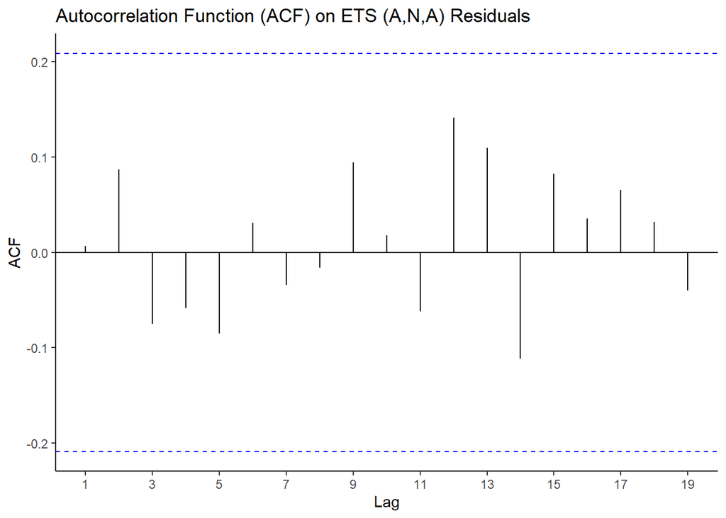

```r
## Next lets look at the ACF plot
ggAcf(final_ets_store_20974$residuals, main = 'Autocorrelation Function (ACF) on ETS (A,N,A) Residuals') +
  theme(panel.grid.major = element_blank(), panel.grid.minor = element_blank(), panel.background = element_blank(), axis.line = element_line(colour = "black")) +
  scale_x_continuous(breaks = seq(1, 22, by = 2))
```

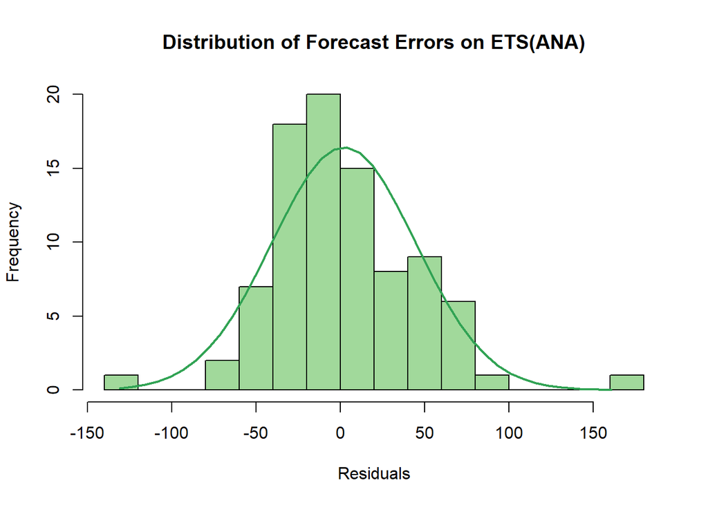

```r
## Histogram of residuals
h <- hist(final_ets_store_20974$residuals, breaks = 20, col = '#a1d99b',
          main = 'Distribution of Forecast Errors on ETS(ANA)', xlab = 'Residuals')
xfit<-seq(min(final_ets_store_20974$residuals),max(final_ets_store_20974$residuals),length=40)
yfit<-dnorm(xfit,mean=mean(final_ets_store_20974$residuals),sd=sd(final_ets_store_20974$residuals))
yfit <- yfit*diff(h$mids[1:2])*length(final_ets_store_20974$residuals)
lines(xfit, yfit, col="#31a354", lwd=2)
```

### ARIMA Forecast Models

The next step in the project is to develop and ARIMA model that is able to forecast lettuce demand. The ARIMA model will then be compared with the final ETS model above to determine what the truest and most accurate forecast model is.

The outlined tests are completed below in order to determine any trends that might or might not have to be taken into account in the ARIMA model.

```r
## ARIMA Model store 20974
## Arima Model
## Testing if timeseries of store is stationary
adf.test(ts_store_20974) ## Augmented Dickey–Fuller (ADF) t-statistic test to find if the series has a unit root (a series with a trend line will have a unit root and result in a large p-value)
```

```
##
##  Augmented Dickey-Fuller Test
##
## data:  ts_store_20974
## Dickey-Fuller = -4.2042, Lag order = 4, p-value = 0.01
## alternative hypothesis: stationary
```

```r
kpss.test(ts_store_20974, null = 'Trend') ## Kwiatkowski-Phillips-Schmidt-Shin (KPSS) tests he null hypothesis of trend stationarity (a low p-value will indicate a signal that is not trend stationary, has a unit root)
```

```
##
##  KPSS Test for Trend Stationarity
##
## data:  ts_store_20974
## KPSS Trend = 0.19453, Truncation lag parameter = 3, p-value = 0.01805
```

```r
ndiffs(ts_store_20974)
```

```
## [1] 0
```

```r
nsdiffs(ts_store_20974)
```

```
## [1] 0
```

```r
pp.test(ts_store_20974)
```

```
##
##  Phillips-Perron Unit Root Test
##
## data:  ts_store_20974
## Dickey-Fuller Z(alpha) = -61.65, Truncation lag parameter = 3, p-value
## = 0.01
## alternative hypothesis: stationary
```

[figure not shown]

```r
## Next lets look at the ACF plot for the differences
ggAcf(ts_store_20974, main = 'Autocorrelation Function (ACF) of Seasonal Differenced Time-Series') +
  theme(panel.grid.major = element_blank(), panel.grid.minor = element_blank(), panel.background = element_blank(), axis.line = element_line(colour = "black")) +
  scale_x_continuous(breaks = seq(1, 100, by = 2))
```

[figure not shown]

```r
## The partial autocorrelation function gives the partial correlation of a stationary time series with its own lagged values, regressed the values of the time series at all shorter lags. It contrasts with the autocorrelation function, which does not control for other lags.
ggPacf(ts_store_20974, main = 'Partial Autocorrelation Function (PACF) of Seasonal Differenced Time-Series') +
  theme(panel.grid.major = element_blank(), panel.grid.minor = element_blank(), panel.background = element_blank(), axis.line = element_line(colour = "black")) +
  scale_x_continuous(breaks = seq(1, 100, by = 2))
```

```r
## Initial auto.arima model that finds 'best model'
auto.arima(ts_store_20974, trace = TRUE, ic = 'bic') ## Best model is determined to be: Best model: ARIMA(0,0,0)(1,0,0)[7] log likelihood=-468.43
```

```
##
##  ARIMA(2,0,2)(1,0,1)[7] with non-zero mean : Inf
##  ARIMA(0,0,0)           with non-zero mean : 960.1969
##  ARIMA(1,0,0)(1,0,0)[7] with non-zero mean : 951.7335
##  ARIMA(0,0,1)(0,0,1)[7] with non-zero mean : 955.341
##  ARIMA(0,0,0)           with zero mean     : 1208.366
##  ARIMA(1,0,0)           with non-zero mean : 958.3436
##  ARIMA(1,0,0)(2,0,0)[7] with non-zero mean : 955.1097
##  ARIMA(1,0,0)(1,0,1)[7] with non-zero mean : Inf
##  ARIMA(1,0,0)(0,0,1)[7] with non-zero mean : 954.6807
##  ARIMA(1,0,0)(2,0,1)[7] with non-zero mean : 959.528
##  ARIMA(0,0,0)(1,0,0)[7] with non-zero mean : 950.3007
##  ARIMA(0,0,0)(2,0,0)[7] with non-zero mean : 953.164
##  ARIMA(0,0,0)(1,0,1)[7] with non-zero mean : 953.0715
##  ARIMA(0,0,0)(0,0,1)[7] with non-zero mean : 954.7562
##  ARIMA(0,0,0)(2,0,1)[7] with non-zero mean : 957.2967
##  ARIMA(0,0,1)(1,0,0)[7] with non-zero mean : 952.2418
##  ARIMA(1,0,1)(1,0,0)[7] with non-zero mean : 955.9064
##  ARIMA(0,0,0)(1,0,0)[7] with zero mean     : Inf
##
##  Best model: ARIMA(0,0,0)(1,0,0)[7] with non-zero mean
```

```
## Series: ts_store_20974
## ARIMA(0,0,0)(1,0,0)[7] with non-zero mean
##
## Coefficients:
##         sar1      mean
##       0.4179  218.5034
## s.e.  0.1034    8.5526
##
## sigma^2 estimated as 2480:  log likelihood=-468.43
## AIC=942.87   AICc=943.15   BIC=950.3
```

```r
## AIC=942.87   AICc=943.15   BIC=950.3
```

### Manual ARIMA Functions

All the tests above, along with the best model of the auto.arima() should be a possible form or variation of ARIMA(p,0,q)(P,0,Q). The section below tests variations of the possible base form.

```r
## Testing various Arima models using lambda = 0 to estimate log data
arima1_store_20974 <- Arima(ts_store_20974, order = c(1, 0, 0))
arima2_store_20974 <- Arima(ts_store_20974, order = c(1, 0, 0), seasonal = list(order = c (1, 0, 0), period = 7))
arima3_store_20974 <- Arima(ts_store_20974, order = c(0, 0, 1), seasonal = list(order = c (0, 0, 1), period = 7))
arima4_store_20974 <- Arima(ts_store_20974, order = c(1, 0, 0))
arima5_store_20974 <- Arima(ts_store_20974, order = c(1, 0, 0), seasonal = list(order = c (2, 0, 0), period = 7))
arima6_store_20974 <- Arima(ts_store_20974, order = c(0, 0, 0), seasonal = list(order = c (2, 0, 0), period = 7))
arima7_store_20974 <- Arima(ts_store_20974, order = c(0, 0, 0), seasonal = list(order = c (1, 0, 0), period = 7))
arima8_store_20974 <- Arima(ts_store_20974, order = c(0, 0, 1), seasonal = list(order = c (1, 0, 0), period = 7))
arima9_store_20974 <- Arima(ts_store_20974, order = c(0, 0, 0), seasonal = list(order = c (1, 0, 1), period = 7))
arima10_store_20974 <- Arima(ts_store_20974, order = c(0, 0, 0), seasonal = list(order = c (2, 0, 0), period = 7))
arima11_store_20974 <- Arima(ts_store_20974, order = c(0, 0, 0), seasonal = list(order = c (3, 0, 0), period = 7))
arima12_store_20974 <- Arima(ts_store_20974, order = c(0, 0, 0), seasonal = list(order = c (2, 0, 1), period = 7))
```

The forecast function is used on each ARIMA model and used with a 14 number period forecast.

```r
## Forecast
forecast_arima1_store20974 <- forecast(arima1_store_20974, h = 14)
forecast_arima2_store20974 <- forecast(arima2_store_20974, h = 14)
forecast_arima3_store20974 <- forecast(arima3_store_20974, h = 14)
forecast_arima4_store20974 <- forecast(arima4_store_20974, h = 14)
forecast_arima5_store20974 <- forecast(arima5_store_20974, h = 14)
forecast_arima6_store20974 <- forecast(arima6_store_20974, h = 14)
forecast_arima7_store20974 <- forecast(arima7_store_20974, h = 14)
forecast_arima8_store20974 <- forecast(arima8_store_20974, h = 14)
forecast_arima9_store20974 <- forecast(arima9_store_20974, h = 14)
forecast_arima10_store20974 <- forecast(arima10_store_20974, h = 14)
forecast_arima11_store20974 <- forecast(arima11_store_20974, h = 14)
forecast_arima12_store20974 <- forecast(arima12_store_20974, h = 14)
```

### In-Sample Comparison

```r
## Accuracy stores Training Sets
accuracy_arima_20974 <- rbind(accuracy(forecast_arima1_store20974), accuracy(forecast_arima2_store20974), accuracy(forecast_arima3_store20974),
           accuracy(forecast_arima4_store20974), accuracy(forecast_arima5_store20974), accuracy(forecast_arima6_store20974),
           accuracy(forecast_arima7_store20974), accuracy(forecast_arima8_store20974), accuracy(forecast_arima9_store20974),
           accuracy(forecast_arima10_store20974), accuracy(forecast_arima11_store20974), accuracy(forecast_arima12_store20974))

accuracy_arima_20974_k <- data.frame(accuracy_arima_20974,
                                     row.names = c('ARIMA(1,0,0)', 'ARIMA(1,0,0)(1,0,0)', 'ARIMA(0,0,1)(0,0,1)',
                                                   'ARIMA(2,0,0)', 'ARIMA(1,0,0)(2,0,0)', 'ARIMA(0,0,1)(2,0,0)',
                                                   'ARIMA(0,0,0)(1,0,0)', 'ARIMA(0,0,1)(1,0,0)', 'ARIMA(0,0,0)(1,0,1)',
                                                   'ARIMA(0,0,0)(2,0,0)','ARIMA(0,0,0)(3,0,0))','ARIMA(0,0,0)(2,0,1)'))

accuracy_arima_20974_k %>%  kable(caption = "Accuracy of ARIMA1 Model", align = 'c') %>%  kable_styling(full_width = F)
```

Accuracy of ARIMA1 Model

[output not shown]

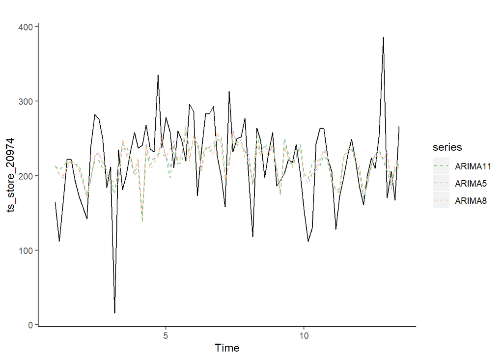

```r
## Plotting the best three models (lowest training set RMSE)
autoplot(ts_store_20974) +
  autolayer(fitted(forecast_arima5_store20974), series = 'ARIMA5', na.rm=TRUE, linetype = "dashed") +
  autolayer(fitted(forecast_arima8_store20974), series = 'ARIMA8', na.rm=TRUE, linetype = 'dashed') +
  autolayer(fitted(forecast_arima11_store20974), series = 'ARIMA11', na.rm=TRUE, linetype = "dashed") +
  scale_color_manual(values = c('#7fc97f' ,'#beaed4', '#fdc086')) +
  theme(panel.grid.major = element_blank(), panel.grid.minor = element_blank(), panel.background = element_blank(), axis.line = element_line(colour = "black"))
```

### Creating, Forecasting and Visualizing ARIMA(p,0,q)(P,0,Q) on Training Set

Following the same Training-Test Set approach introduced in the computations of the Exponential Smoothing models, the in-sample and out-of-sample performance of the above ARIMA models need to be compared in order to find the best one that best fits. More specifically, every model is trained on the Training set (first 70 days of time-series, 80% of the entire time series for store number 20974) then predicts the demand for the next 18 days. The evaluation of the predictions is based on the Test set (last 18 days of initial time-series, 20% of the entire time series for store number 20974) and based on those values the forecast errors of each model are computed.

```r
## Train best models on training set
training_arima5_store_20974 <- Arima(training_ts_store_20974, order = c(1, 0, 0), seasonal = list(order = c (2, 0, 0), period = 7))
training_arima8_store_20974 <- Arima(training_ts_store_20974, order = c(0, 0, 1), seasonal = list(order = c (1, 0, 0), period = 7))
training_arima11_store_20974 <- Arima(training_ts_store_20974, order = c(0, 0, 0), seasonal = list(order = c (3, 0, 0), period = 7))

## Forecast using the best models
forecast_arima5_store20974 <- forecast(training_arima5_store_20974, h = 18)
forecast_arima8_store20974 <- forecast(training_arima8_store_20974, h = 18)
forecast_arima11_store20974 <- forecast(training_arima11_store_20974, h = 18)

## Test models on out-of sample test set to determine final, best, model
accuracy_final_arima_20974 <- rbind(accuracy(forecast_arima5_store20974, test_ts_store_20974),
                              accuracy(forecast_arima8_store20974, test_ts_store_20974),
                              accuracy(forecast_arima11_store20974, test_ts_store_20974))

accuracy_final_arima_20974_k <- data.frame(accuracy_final_arima_20974, row.names = c('Train', 'Test', 'Train_2', 'Test_2', 'Train_3', 'Test_3'))

accuracy_final_arima_20974_k %>%  kable(caption = "Accuracy of ARIMA Models", align = 'c') %>%  kable_styling(full_width = F) %>%
  pack_rows("ARIMA(1,0,0)(2,0,0)", 1, 2) %>%
  pack_rows("ARIMA(0,0,1)(1,0,0)", 3, 4) %>%
  pack_rows("ARIMA(0,0,0)(3,0,0))", 5, 6)
```

Accuracy of ARIMA Models

|  | ME | RMSE | MAE | MPE | MAPE | MASE | ACF1 |
| --- | --- | --- | --- | --- | --- | --- | --- |
| **ARIMA(1,0,0)(2,0,0)** |  |  |  |  |  |  |  |
| Train | 1.6540687 | 47.95139 | 38.95650 | -17.768157 | 33.05058 | 0.8495570 | -0.0178332 |
| Test | 0.9368141 | 47.75891 | 29.45196 | -4.013985 | 13.50910 | 0.6422835 | NA |
| **ARIMA(0,0,1)(1,0,0)** |  |  |  |  |  |  |  |
| Train_2 | 1.3122305 | 48.61274 | 38.78247 | -18.941275 | 33.96957 | 0.8457618 | 0.0247216 |
| Test_2 | -1.8268441 | 49.12370 | 32.22283 | -5.550662 | 15.02731 | 0.7027102 | NA |
| **ARIMA(0,0,0)(3,0,0))** |  |  |  |  |  |  |  |
| Train_3 | 1.6669510 | 49.14791 | 39.81523 | -17.402311 | 32.94647 | 0.8682840 | 0.2153363 |
| Test_3 | 0.6806324 | 48.13408 | 30.63078 | -4.136784 | 14.12786 | 0.6679910 | NA |

### Final ARIMA Model

The best ARIMA model is trained once again on the entire time series of store 20974 in order to provide the most accurate forecast for the 14 day lettuce demand. The model final forecast for the lettuce demand using the ARIMA(1, 0, 0)(2, 0, 0)[7] is modeled below.

```r
## Train best model on the entire dataset from store 20974]
best_arima5_store_20974 <- Arima(ts_store_20974, order = c(1, 0, 0), seasonal = list(order = c (2, 0, 0), period = 7))
forecast_best_arima_store_20974 <- forecast(best_arima5_store_20974, h = 14)

# Best model table
forecast_best_arima_store_20974_k <- data.frame(forecast_best_arima_store_20974,
                                                row.names = c('16/06/15', '17/06/15', '18/06/15', '19/06/15', '20/06/15', '21/06/15',
                                                              '22/06/15', '23/06/15', '24/06/15', '25/06/15', '26/06/15', '27/06/15',
                                                              '28/06/15', '29/06/15'))
forecast_best_arima_store_20974_k %>%  kable(caption = "Final 14 Day ARIMA Forecast", align = 'c') %>%  kable_styling(full_width = F)
```

Final 14 Day ARIMA Forecast

|  | Point.Forecast | Lo.80 | Hi.80 | Lo.95 | Hi.95 |
| --- | --- | --- | --- | --- | --- |
| 16/06/15 | 225.0381 | 161.9666 | 288.1096 | 128.5785 | 321.4976 |
| 17/06/15 | 236.1516 | 172.1403 | 300.1628 | 138.2548 | 334.0483 |
| 18/06/15 | 274.9644 | 210.9252 | 339.0037 | 177.0249 | 372.9040 |
| 19/06/15 | 197.9999 | 133.9598 | 262.0400 | 100.0590 | 295.9407 |
| 20/06/15 | 207.1209 | 143.0808 | 271.1610 | 109.1800 | 305.0618 |
| 21/06/15 | 198.7878 | 134.7477 | 262.8279 | 100.8469 | 296.7287 |
| 22/06/15 | 234.9984 | 170.9583 | 299.0385 | 137.0576 | 332.9393 |
| 23/06/15 | 219.5166 | 152.0598 | 286.9734 | 116.3503 | 322.6829 |
| 24/06/15 | 228.8890 | 161.3323 | 296.4457 | 125.5699 | 332.2081 |
| 25/06/15 | 257.8649 | 190.3052 | 325.4246 | 154.5412 | 361.1886 |
| 26/06/15 | 205.5278 | 137.9680 | 273.0876 | 102.2040 | 308.8516 |
| 27/06/15 | 213.0050 | 145.4452 | 280.5648 | 109.6812 | 316.3288 |
| 28/06/15 | 205.4249 | 137.8651 | 272.9847 | 102.1011 | 308.7487 |
| 29/06/15 | 229.7271 | 162.1672 | 297.2869 | 126.4032 | 333.0509 |

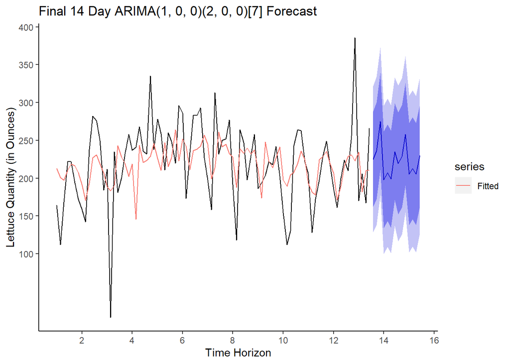

```r
## Best model plotted
autoplot(forecast_best_arima_store_20974, main = 'Final 14 Day ARIMA(1, 0, 0)(2, 0, 0)[7] Forecast',
         ylab = 'Lettuce Quantity (in Ounces)', xlab = 'Time Horizon') +
  autolayer(fitted(forecast_best_arima_store_20974), series = 'Fitted', na.rm=TRUE) +
  scale_x_continuous(breaks = seq(0, 22, by = 2)) +
  theme(panel.grid.major = element_blank(), panel.grid.minor = element_blank(),
        panel.background = element_blank(), axis.line = element_line(colour = "black")) +
  scale_y_continuous(breaks = c(100, 150, 200, 250, 300, 350, 400, 450, 500, 550))
```

### Forecast Further Improvements

The model must be checked by a residual analysis to see for further improvements. Much like the ETS model, there needs to be no correlations between the forecast errors of the model in the time series.

Using ggplots, ggACF() function, lags 1 - 19 are visually displayed. Obsebserving this ACF plot allows us to see that there is no serial autocorrelation between lags 1-19.

The forecast errors’ constant variance is tested by a time plot of the in-sample forecast errors, whereas their normal distribution with zero mean by a histogram plot of the forecast errors, with an overlaid normal curve that has mean zero and the same standard deviation as the distribution of forecast errors.

```r
## Ljung-Box Test
Box.test(forecast_best_arima_store_20974$residuals, lag = 20, type = 'Ljung-Box')
```

```
##
##  Box-Ljung test
##
## data:  forecast_best_arima_store_20974$residuals
## X-squared = 11.919, df = 20, p-value = 0.9188
```

[figure not shown]

```r
## These plots are descriptive but they can be improved to increase interpretability by plotting and optimising each one individually
## Lets focus on the residuals plot in order to determine if they have constant variance (desired)
autoplot(forecast_best_arima_store_20974$residuals, main = 'Forecast Errors ARIMA(1, 0, 0)(2, 0, 0)[7])',
         ylab = 'ARIMA(0, 0, 0)(1, 0, 1)[7] Residuals', col = 'steelblue') +
  scale_x_continuous(breaks = seq(5, 22, by = 2)) +
  theme(panel.grid.major = element_blank(), panel.grid.minor = element_blank(),
        panel.background = element_blank(), axis.line = element_line(colour = "black"))
```

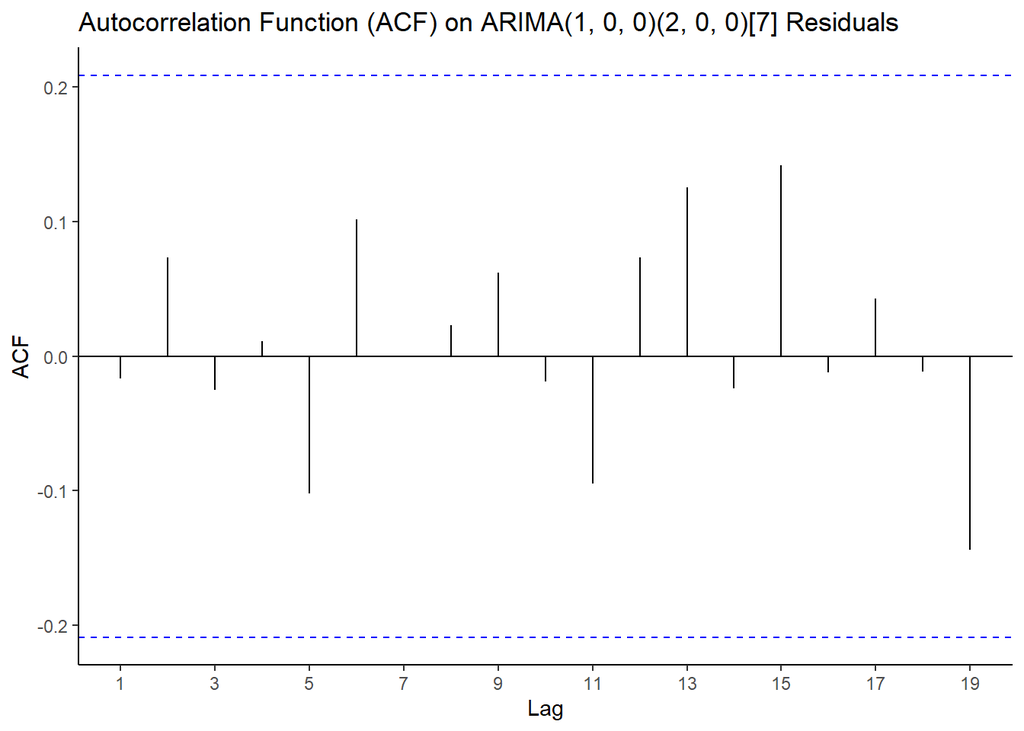

```r
## Next lets look at the ACF plot
ggAcf(forecast_best_arima_store_20974$residuals,
      main = 'Autocorrelation Function (ACF) on ARIMA(1, 0, 0)(2, 0, 0)[7] Residuals') +
  theme(panel.grid.major = element_blank(), panel.grid.minor = element_blank(),
        panel.background = element_blank(), axis.line = element_line(colour = "black")) +
  scale_x_continuous(breaks = seq(1, 100, by = 2))
```

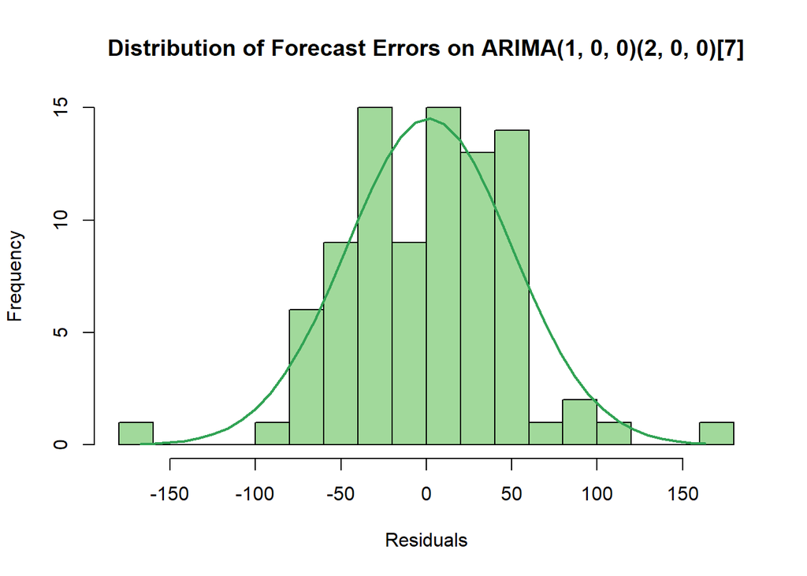

```r
## Histogram
h <- hist(forecast_best_arima_store_20974$residuals, breaks = 20, col = '#a1d99b',
          main = 'Distribution of Forecast Errors on ARIMA(1, 0, 0)(2, 0, 0)[7]', xlab = 'Residuals')
xfit<-seq(min(forecast_best_arima_store_20974$residuals),max(forecast_best_arima_store_20974$residuals),length=40)
yfit<-dnorm(xfit,mean=mean(forecast_best_arima_store_20974$residuals),sd=sd(forecast_best_arima_store_20974$residuals))
yfit <- yfit*diff(h$mids[1:2])*length(forecast_best_arima_store_20974$residuals)
lines(xfit, yfit, col="#31a354", lwd=2)
```

The plotted residuals and the histogram show that the forecast errors have constant variance over time and are normally distributed with mean of zero. It is conclusive that ARIMA(1, 0, 0)(2, 0, 0)[7] provides an adequate preditive model for the lettuce demand of store 20974.

### Final Forecast for Resturant 20974: ETS(A,N,A) vs. ARIMA(1, 0, 0)(2, 0, 0)[7])

The candidate models have been determined to the ETS(A,N,A) and the ARIMA(1, 0, 0)(2, 0, 0)[7] as these had the best in-sample and out-of-sample scores for their respective model classes.

The models are now compared against eachother below and the model with the lowest RMSE will be determined the best model for lettuce demand forecasting for store 20974.

```r
## Checking which model based on RMSE (ETS or ARIMA)
accuracy_final_model_all_20974 <- rbind(accuracy(forecast_ets_store_20974, test_ts_store_20974),
                              accuracy(forecast_arima5_store20974, test_ts_store_20974))

accuracy_final_model_all_20974_k <- data.frame(accuracy_final_model_all_20974,
                                               row.names = c('Train', 'Test', 'Train_2', 'Test_2'))

accuracy_final_model_all_20974_k %>%  kable(caption = "Accuracy of Best ETS and ARIMA", align = 'c') %>%
  kable_styling(full_width = F) %>%
  pack_rows("ETS(A,N,A)", 1, 2) %>%
  pack_rows("ARIMA(1,0,0)(2,0,0)", 3, 4)
```

Accuracy of Best ETS and ARIMA

|  | ME | RMSE | MAE | MPE | MAPE | MASE | ACF1 |
| --- | --- | --- | --- | --- | --- | --- | --- |
| **ETS(A,N,A)** |  |  |  |  |  |  |  |
| Train | -0.5314202 | 41.53243 | 34.24962 | -13.4603626 | 26.57567 | 0.7469102 | 0.0831474 |
| Test | 7.9390062 | 47.20564 | 29.52803 | 0.6841513 | 12.93265 | 0.6439426 | NA |
| **ARIMA(1,0,0)(2,0,0)** |  |  |  |  |  |  |  |
| Train_2 | 1.6540687 | 47.95139 | 38.95650 | -17.7681568 | 33.05058 | 0.8495570 | -0.0178332 |
| Test_2 | 0.9368141 | 47.75891 | 29.45196 | -4.0139852 | 13.50910 | 0.6422835 | NA |

ETS(A,N,A) appears to fit the data better than the ARIMA model and similarly has better forecasting power than the ARIMA model. This is based on the in-sample (Training set) and out-of-sample (Test set) RMSE scores. It is therefore selected as the final forecast model for store number 20794. It is trained on the entire time series in order to enhance its forecasting power, and made to forecast 14 days.

The final forecast of lettuce demand for store number 20794 from 06/16/2015 to 06/29/2015 is saved on a csv file.

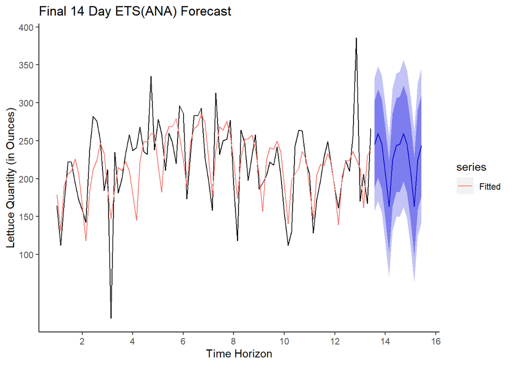

```r
## Final model for store 20974
final_store_20974 <- forecast(ets_store_20974, h = 14)
autoplot(final_store_20974, main = 'Final 14 Day ETS(ANA) Forecast', ylab = 'Lettuce Quantity (in Ounces)',
         xlab = 'Time Horizon') +
  autolayer(fitted(final_store_20974), series = 'Fitted', na.rm=TRUE) +
  scale_x_continuous(breaks = seq(0, 22, by = 2)) +
  theme(panel.grid.major = element_blank(), panel.grid.minor = element_blank(),
        panel.background = element_blank(), axis.line = element_line(colour = "black")) +
  scale_y_continuous(breaks = c(100, 150, 200, 250, 300, 350, 400, 450, 500, 550))
```

```r
## Forecast results to csv
write.csv(final_store_20974, 'store_20974_forecast.csv')

## Final Forecast (Table)
final_store_20974_k <- data.frame(final_store_20974,
                                  row.names = c('16/06/15', '17/06/15', '18/06/15', '19/06/15', '20/06/15', '21/06/15', '22/06/15',
                                                '23/06/15', '24/06/15', '25/06/15', '26/06/15', '27/06/15', '28/06/15', '29/06/15'))
final_store_20974_k %>%  kable(caption = "Final 14 Day ETS (ANA) Forecast", align = 'c') %>%  kable_styling(full_width = F)
```

Final 14 Day ETS (ANA) Forecast

|  | Point.Forecast | Lo.80 | Hi.80 | Lo.95 | Hi.95 |
| --- | --- | --- | --- | --- | --- |
| 16/06/15 | 245.3543 | 187.86551 | 302.8431 | 157.43279 | 333.2758 |
| 17/06/15 | 259.3771 | 201.13770 | 317.6166 | 170.30761 | 348.4466 |
| 18/06/15 | 245.3595 | 186.37898 | 304.3400 | 155.15658 | 335.5624 |
| 19/06/15 | 207.5218 | 147.80939 | 267.2342 | 116.19955 | 298.8440 |
| 20/06/15 | 163.0179 | 102.58243 | 223.4533 | 70.58984 | 255.4459 |
| 21/06/15 | 224.4164 | 163.26647 | 285.5663 | 130.89565 | 317.9371 |
| 22/06/15 | 244.1267 | 182.26971 | 305.9837 | 149.52459 | 338.7289 |
| 23/06/15 | 245.3543 | 182.79903 | 307.9096 | 149.68427 | 341.0243 |
| 24/06/15 | 259.3771 | 196.13132 | 322.6229 | 162.65102 | 356.1032 |
| 25/06/15 | 245.3595 | 181.43061 | 309.2884 | 147.58870 | 343.1303 |
| 26/06/15 | 207.5218 | 142.91705 | 272.1265 | 108.71737 | 306.3262 |
| 27/06/15 | 163.0179 | 97.74427 | 228.2915 | 63.19051 | 262.8452 |
| 28/06/15 | 224.4164 | 158.48071 | 290.3521 | 123.57647 | 325.2563 |
| 29/06/15 | 244.1267 | 177.53475 | 310.7187 | 142.28309 | 345.9704 |

## Conclusion

This paper has looked at historic lettuce demand for four resturants in the United States. It has used the historic data to individually find the best model, out of a array of Holt-Winters, ETS, and ARIMA forecasts, in order to help store managers prepare for future needs. It is clear to the author that each individual forecast needs to be examined as its own problem and historic data clearly impacts what model is best to use when trying to predict future demand.